# Appendix S1. Linear regression models and non-linear population dynamics

## HMSC statistical model

```r
dat <- as.data.frame(log(N))
dat$time <- 1:t
df <- data.frame(dat[(2:t), -3])
Y <- as.matrix(df)
# prepare data in HMSC format
XData <- data.frame(dat[1:(t - 1), -3], E[1:(t - 1)], E[1:(t - 1)]^2)
colnames(XData) <- c(paste0("n", 1:length(r)), "E", "Esq")
studyDesign = data.frame(sample = as.factor(1:(t - 1)))
rL = HmscRandomLevel(units = studyDesign$sample)
m.5.hmsc = Hmsc(Y = Y, XData = XData, XFormula = ~E + Esq, studyDesign = studyDesign,
    ranLevels = list(sample = rL))
# Bayesian model parameters
nChains <- 2
thin <- 5
samples <- 1000
transient <- 500 * thin
verbose <- 500 * thin
# sample MCMC
m.5.sample <- sampleMcmc(m.5.hmsc, thin = thin, sample = samples, transient = transient,
    nChains = nChains, verbose = verbose)
```

```
#> Computing chain 1
#> Chain 1, iteration 2500 of 7500 (transient)
#> Chain 1, iteration 5000 of 7500 (sampling)
#> Chain 1, iteration 7500 of 7500 (sampling)
#> Computing chain 2
#> Chain 2, iteration 2500 of 7500 (transient)
#> Chain 2, iteration 5000 of 7500 (sampling)
#> Chain 2, iteration 7500 of 7500 (sampling)
```

```r
m5.post.hmsc <- convertToCodaObject(m.5.sample)
summary(m5.post.hmsc$Beta)
```

```
#>
#> Iterations = 2505:7500
#> Thinning interval = 5
#> Number of chains = 2
#> Sample size per chain = 1000
#>
#> 1. Empirical mean and standard deviation for each variable,
#>    plus standard error of the mean:
#>
#>                                 Mean     SD Naive SE Time-series SE
#> B[(Intercept) (C1), N1 (S1)]  3.7701 1.2830  0.02869        0.03113
#> B[E (C2), N1 (S1)]            0.9876 2.4710  0.05525        0.06060
#> B[Esq (C3), N1 (S1)]         -1.8970 1.1987  0.02680        0.02944
#> B[(Intercept) (C1), N2 (S2)]  1.4760 0.7564  0.01691        0.01636
#> B[E (C2), N2 (S2)]            3.7344 1.5249  0.03410        0.03307
#> B[Esq (C3), N2 (S2)]         -1.8451 0.7474  0.01671        0.01629
#>
#> 2. Quantiles for each variable:
#>
#>                                  2.5%     25%    50%    75%   97.5%
#> B[(Intercept) (C1), N1 (S1)]  1.27165  2.9198  3.764  4.588  6.4240
#> B[E (C2), N1 (S1)]           -4.02211 -0.6079  1.056  2.593  5.8051
#> B[Esq (C3), N1 (S1)]         -4.23771 -2.6601 -1.899 -1.167  0.4855
#> B[(Intercept) (C1), N2 (S2)]  0.03592  0.9845  1.465  1.960  2.9788
#> B[E (C2), N2 (S2)]            0.59060  2.7442  3.777  4.717  6.6489
#> B[Esq (C3), N2 (S2)]         -3.25030 -2.3306 -1.860 -1.364 -0.3263
```

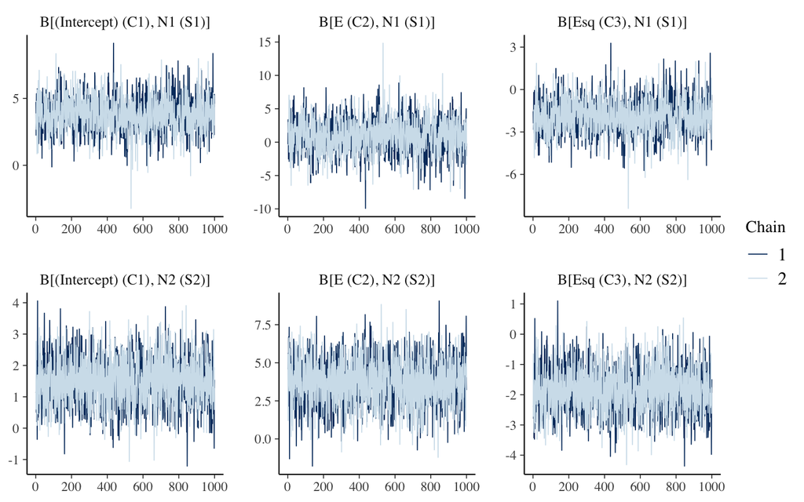

```r
bayesplot::mcmc_trace(m5.post.hmsc$Beta)
```

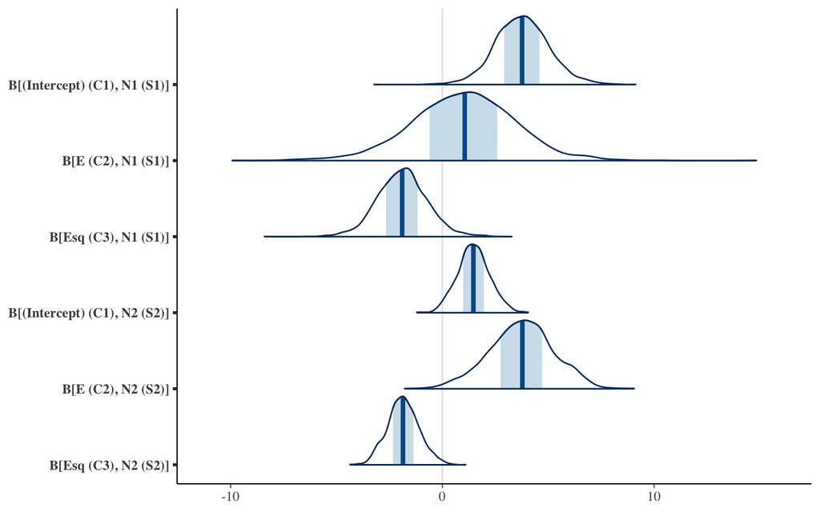

```r
bayesplot::mcmc_areas(m5.post.hmsc$Beta, area_method = c("equal height"))
```

```r
# Bayesian estimates
summary(m5.post.hmsc$Beta)$statistics[1:4, 1:2]
```

```
#>                                    Mean        SD
#> B[(Intercept) (C1), N1 (S1)]  3.7701166 1.2829827
#> B[E (C2), N1 (S1)]            0.9876064 2.4710204
#> B[Esq (C3), N1 (S1)]         -1.8969594 1.1987431
#> B[(Intercept) (C1), N2 (S2)]  1.4759806 0.7564327
```

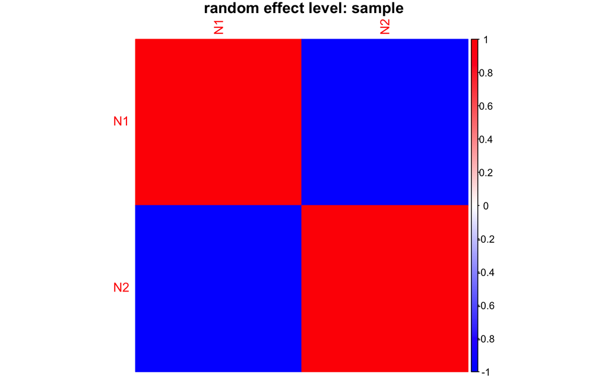

```r
OmegaCor = computeAssociations(m.5.sample)
supportLevel = 0.95
toPlot = ((OmegaCor[[1]]$support > supportLevel) + (OmegaCor[[1]]$support < (1 -
    supportLevel)) > 0) * OmegaCor[[1]]$mean
corrplot::corrplot(toPlot, method = "color", col = colorRampPalette(c("blue", "white",
    "red"))(200), title = paste("random effect level:", m.5.sample$rLNames[1]), mar = c(0,
    0, 1, 0))
```

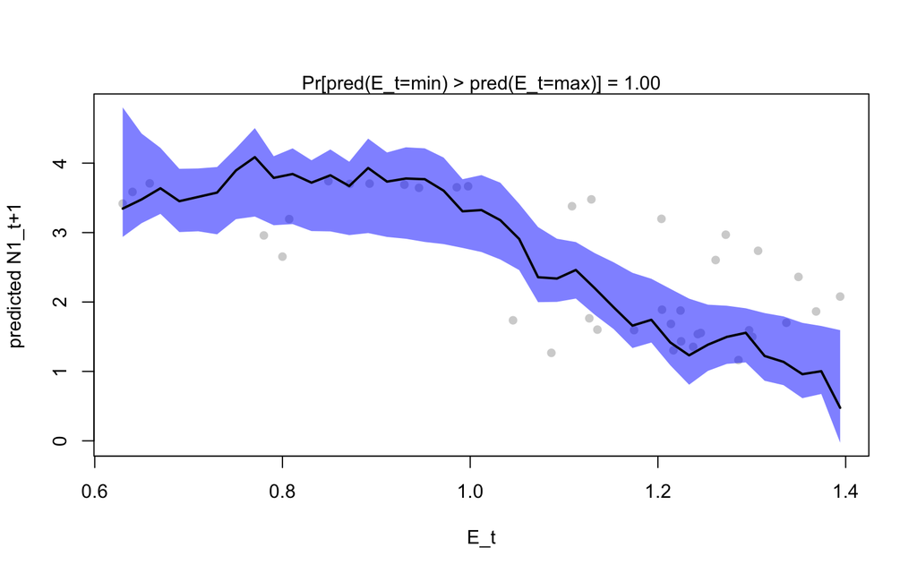

```r
Gradient <- constructGradient(m.5.sample, focalVariable = "E", non.focalVariables = list(Esq = list(2)),
    ngrid = 39)
predY <- predict(m.5.sample, XData = Gradient$XDataNew, expected = TRUE)
a <- plotGradient(m.5.sample, Gradient, pred = predY, showData = T, measure = "Y",
    index = 1, main = "", xlab = "E_t", ylab = "predicted N1_t+1")
```

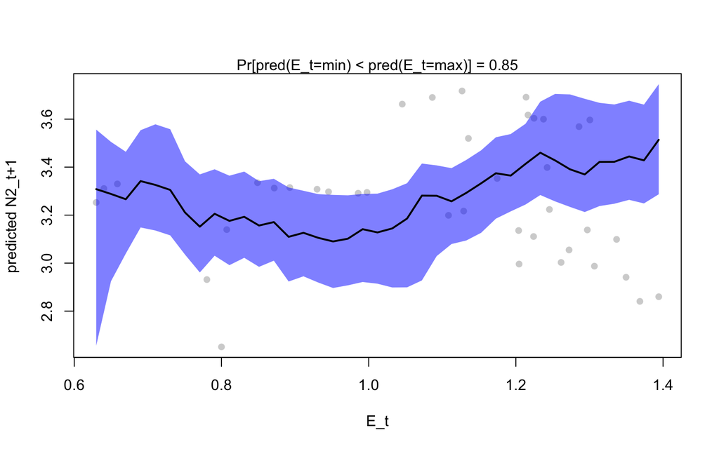

```r
b <- plotGradient(m.5.sample, Gradient, pred = predY, showData = T, measure = "Y",
    index = 2, main = "", xlab = "E_t", ylab = "predicted N2_t+1")
```

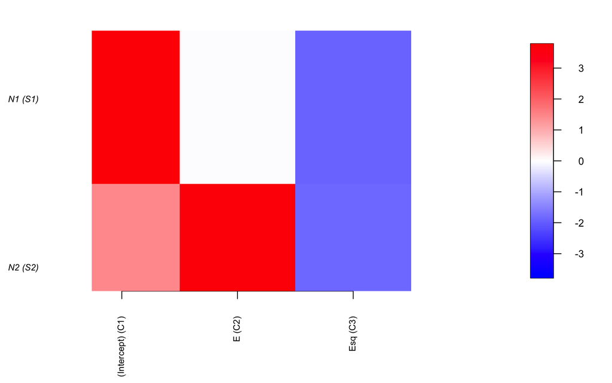

```r
postBeta = getPostEstimate(m.5.sample, parName = "Beta")
plotBeta(m.5.sample, post = postBeta, param = "Mean", supportLevel = 0.7)
```

We can see that the Environment has an overall negative impact for Species 1 as $E$ drifts randomly towards more positive values (and thus further from Species 1 trait value). We also see that the residual species association for species 1 and 2 are negative.

We use variation partition to estimate the relative importance of environment and species associations for species abundances.

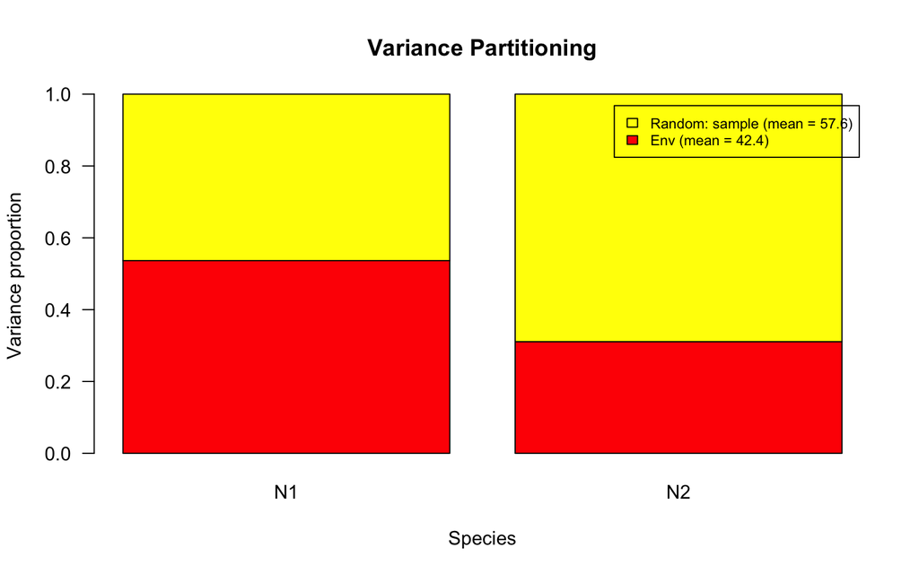

```r
VP <- computeVariancePartitioning(m.5.sample, group = c(1, 1, 1), groupnames = "Env")
plotVariancePartitioning(m.5.sample, VP, args.legend = list(cex = 0.75, bg = "transparent"))
```

```r
# prepare data for HMSC, run later
m.5a1.hmsc = Hmsc(Y = Y[, 1], XData = XData, XFormula = ~n1 + n2 + E + Esq)
m.5a2.hmsc = Hmsc(Y = Y[, 2], XData = XData, XFormula = ~n1 + n2 + E + Esq)
```

We evaluate whether variation partition correctly detects the relative importance of environment and species interactions by greatly increasing the effects of interspecific competition and decreasing the strength of environmental variation.

```r
# Simulate initial species population growth with environment fluctuations
N0 <- c(10, 10)
r <- c(1.7, 1.7)
alpha.11 <- 0.01
alpha.22 <- 0.01
alpha.12 <- 0.015
alpha.21 <- 0.02
alpha <- matrix(c(alpha.11, alpha.21, alpha.12, alpha.22), nrow = 2, byrow = FALSE)
E.0 <- 0.8
x <- c(0.8, 0.8)
# Simulation of model for t time steps
t <- 40
N <- array(NA, dim = c(t, length(N0)))
N <- as.data.frame(N)
colnames(N) <- paste0("N", 1:length(N0))
N[1, ] <- N0
E <- rep(NA, t)
E[1] <- E.0
for (i in 2:t) {
    N[i, ] <- disc_LV_E(r = r, N0 = N[i - 1, ], alpha = alpha, E = E[i - 1], x = x)
    E[i] <- E[i - 1] + rnorm(1, 0, 0.001)
}
```

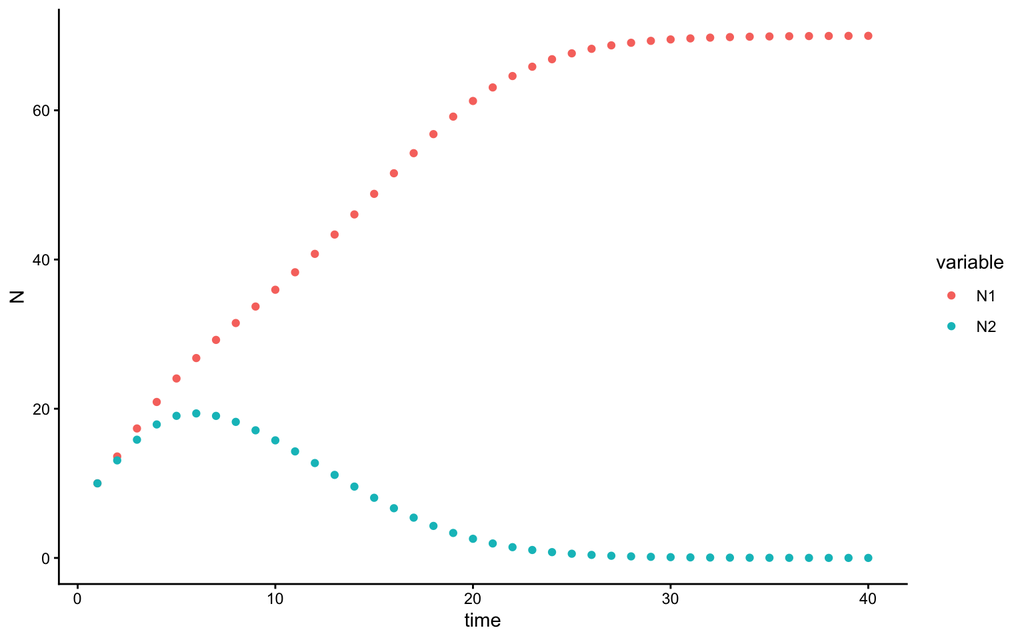

Population size over time for a discrete-time logistic growth model with competition and a changing environment, with parameters $r_1 = r_2$ = 1.7, $N_{i,0}$ = 10, $\alpha_{ii}$ = 0.01, $\alpha_{12}$ = 0.015, and $\alpha_{21}$ = 0.02.

```r
## prepare data in HMSC format
dat <- as.data.frame(log(N))
dat$time <- 1:t
df <- data.frame(dat[(2:t), -3])
Y <- as.matrix(df)
XData <- data.frame(dat[1:(t - 1), -3], E[1:(t - 1)], E[1:(t - 1)]^2)
colnames(XData) <- c(paste0("n", 1:length(r)), "E", "Esq")
studyDesign = data.frame(sample = as.factor(1:(t - 1)))
rL = HmscRandomLevel(units = studyDesign$sample)
m.6.hmsc = Hmsc(Y = Y, XData = XData, XFormula = ~E + Esq, studyDesign = studyDesign,
    ranLevels = list(sample = rL))
# Bayesian model parameters
nChains <- 2
thin <- 5
samples <- 2000
transient <- 100 * thin
verbose <- 500 * thin
# sample MCMC
m.6.sample <- sampleMcmc(m.6.hmsc, thin = thin, sample = samples, transient = transient,
    nChains = nChains, verbose = verbose)
```

```
#> Computing chain 1
#> Chain 1, iteration 2500 of 10500 (sampling)
#> Chain 1, iteration 5000 of 10500 (sampling)
#> Chain 1, iteration 7500 of 10500 (sampling)
#> Chain 1, iteration 10000 of 10500 (sampling)
#> Computing chain 2
#> Chain 2, iteration 2500 of 10500 (sampling)
#> Chain 2, iteration 5000 of 10500 (sampling)
#> Chain 2, iteration 7500 of 10500 (sampling)
#> Chain 2, iteration 10000 of 10500 (sampling)
```

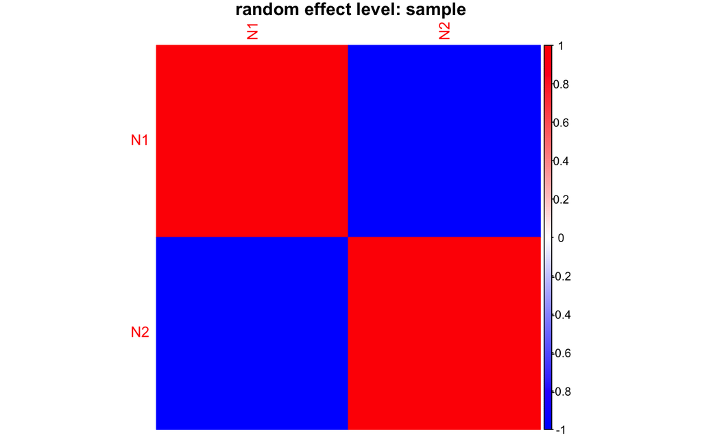

```r
OmegaCor = computeAssociations(m.6.sample)
supportLevel = 0.95
toPlot = ((OmegaCor[[1]]$support > supportLevel) + (OmegaCor[[1]]$support < (1 -
    supportLevel)) > 0) * OmegaCor[[1]]$mean
corrplot::corrplot(toPlot, method = "color", col = colorRampPalette(c("blue", "white",
    "red"))(200), title = paste("random effect level:", m.6.sample$rLNames[1]), mar = c(0,
    0, 1, 0))
```

```r
OmegaCor
```

```
#> [[1]]
#> [[1]]$mean
#>            N1         N2
#> N1  1.0000000 -0.9960107
#> N2 -0.9960107  1.0000000
#>
#> [[1]]$support
#>    N1 N2
#> N1  1  0
#> N2  0  1
```

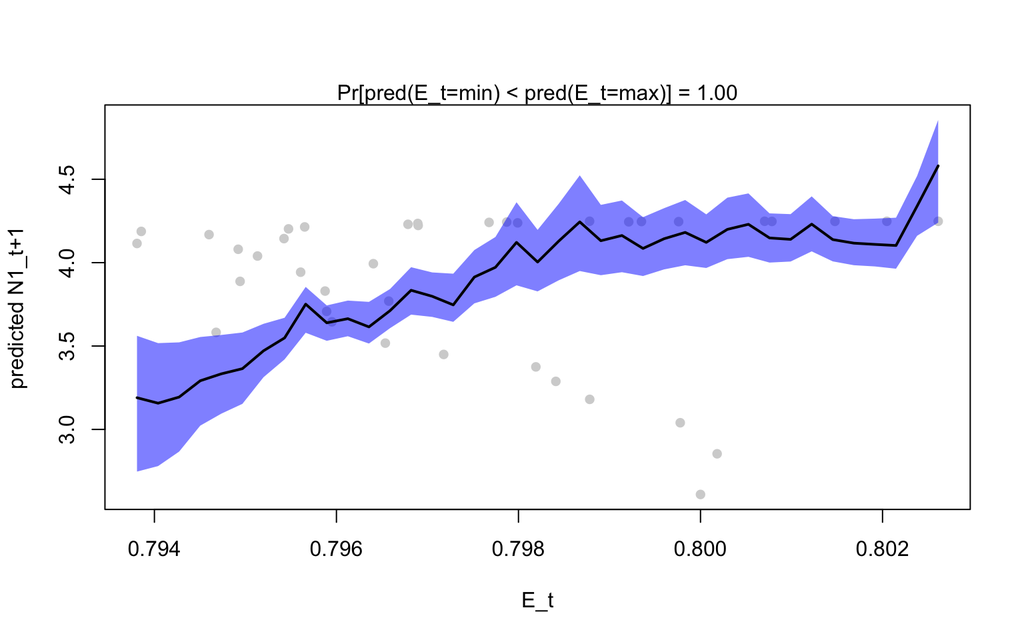

```r
Gradient <- constructGradient(m.6.sample, focalVariable = "E", non.focalVariables = list(Esq = list(2)),
    ngrid = 39)
predY <- predict(m.6.sample, XData = Gradient$XDataNew, expected = TRUE)
a <- plotGradient(m.6.sample, Gradient, pred = predY, showData = T, measure = "Y",
    index = 1, main = "", xlab = "E_t", ylab = "predicted N1_t+1")
```

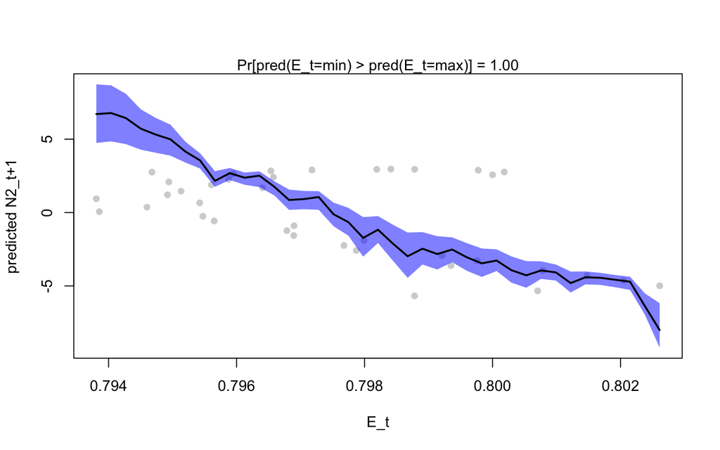

```r
b <- plotGradient(m.6.sample, Gradient, pred = predY, showData = T, measure = "Y",
    index = 2, main = "", xlab = "E_t", ylab = "predicted N2_t+1")
```

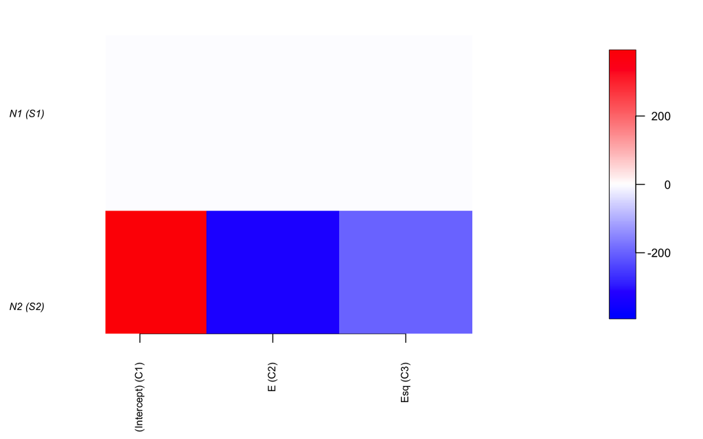

```r
postBeta = getPostEstimate(m.6.sample, parName = "Beta")
plotBeta(m.6.sample, post = postBeta, param = "Mean", supportLevel = 0.7)
```

## Conclusions

With the reduced impact of the environment, we now see the strong negative associations between the two competing species. We also correctly see a relatively weak impact of environment for Species 1 abundance and a stronger impact for Species 2.

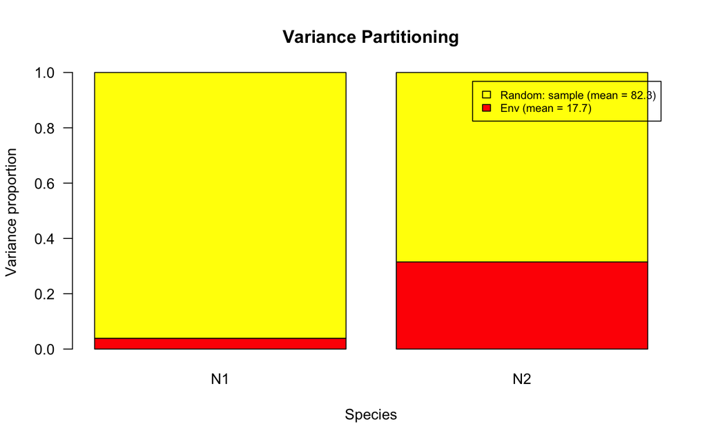

[figure not shown]

Observed (points) and HMSC model-predicted population size (logarithm) for Species 1 (black) and Species 2 (orange), using environment $E_t$ as a fixed effect predictor and specifying temporal random effects to capture the species interactions. Lines represent the 95% highest probability density interval (HPDI) for predictions at each time point.

```r
VP <- computeVariancePartitioning(m.6.sample, group = c(1, 1, 1), groupnames = "Env")
plotVariancePartitioning(m.6.sample, VP, args.legend = list(cex = 0.75, bg = "transparent"))
```

# Model E: Species growth, competition, environmental change, and trait evolution

We now consider that trait evolution can occur, with an impact on the species growth rate / fitness in the context of the environment.

## Trait evolution

Previously the population growth rate was fixed as $r_i = \hat{W}e^{-(E-x_{i,t})^2}$. However, we now introduce the quantitative genetic model of evolutionary rescue (Gomulkiewicz and Holt 1995).

The growth equation for each species now becomes:

$$N_{i,t+1} =\frac{\hat{W}e^
\frac{-[(\frac{w+(1-h^2)P} {P+w})(E-x_{i,t})]^2}{2(P+w)}N_{i,t}} {1 +
\alpha_{ii}N_{i,t} + \alpha_{ij} N_{j,t}}$$

where $\hat{W}$ is calculated as $\hat{W}=W_{max}\sqrt(\frac{w}{P+w})$, $W_{max}$ is the species’ maximum per-capita growth rate, *w* is the width of the Gaussian fitness function (which determines the strength of selection, as increasing values indicate a weaker reduction in fitness with distance from optimum trait value), *P* is the width of the distribution of the phenotype *x*, and $h^2$ is the heritability of the trait *x*. For the simulation we use $W_{max}$ = 2, *P* = 1, and *w* = 2.

The change in the average trait value each time step is given by:

$$d_{i,t+1} = k d_{i,t}$$
where $k = \frac{w + (1-h^2) P}{w + P}$ and $d_{i,t} = E_t - x_{i,t}$.

## Population dynamics simulation

We use one of the same examples as above, with weak strength of interspecific interactions. We use initial trait values that favor the weaker competitor, and we simulate random increasing shifts in the local environment. The simulation uses the `disc_LV_evol` command in the `ecoevor` package.

```r
N0 <- c(10, 10)
alpha.11 <- 0.01
alpha.22 <- 0.01
alpha.12 <- 0.005
alpha.21 <- 0.01
alpha <- matrix(c(alpha.11, alpha.21, alpha.12, alpha.22), nrow = 2, byrow = FALSE)
E.0 <- 0.8
x.0 <- c(0.1, 0.8)
P <- 1
w <- 2
Wmax <- 2
h2 <- 1
k <- (w + (1 - h2) * P)/(P + w)
# Simulation of model for t time steps
t <- 40
N <- array(NA, dim = c(t, length(N0)))
N <- as.data.frame(N)
colnames(N) <- paste0("N", 1:length(N0))
N[1, ] <- N0
E <- rep(NA, t)
E[1] <- E.0
x <- array(NA, dim = c(t, length(N0)))
x <- as.data.frame(x)
colnames(x) <- paste0("x", 1:length(N0))
x[1, ] <- x.0
r <- array(NA, dim = c(t, length(N0)))
r <- as.data.frame(r)
colnames(r) <- paste0("r", 1:length(N0))
What <- Wmax * sqrt(w/(P + w))
r[1, ] <- What * exp((-(((w + (1 - h2) * P)/(P + w)) * (E[1] - x[1, ]))^2)/(2 * (P +
    w)))
for (i in 2:t) {
    res <- disc_LV_evol(N0 = N[i - 1, ], alpha = alpha, E = E[i - 1], x = x[i - 1,
        ], P = P, w = w, Wmax = Wmax, h2 = h2)
    N[i, ] <- res$Nt1
    r[i, ] <- res$r
    # trait change
    d <- E[i - 1] - x[i - 1, ]
    d1 <- k * d
    x[i, ] <- E[i - 1] - d1
    # environmental change
    E[i] <- E[i - 1] + abs(rnorm(1, 0, 0.05))
}
```

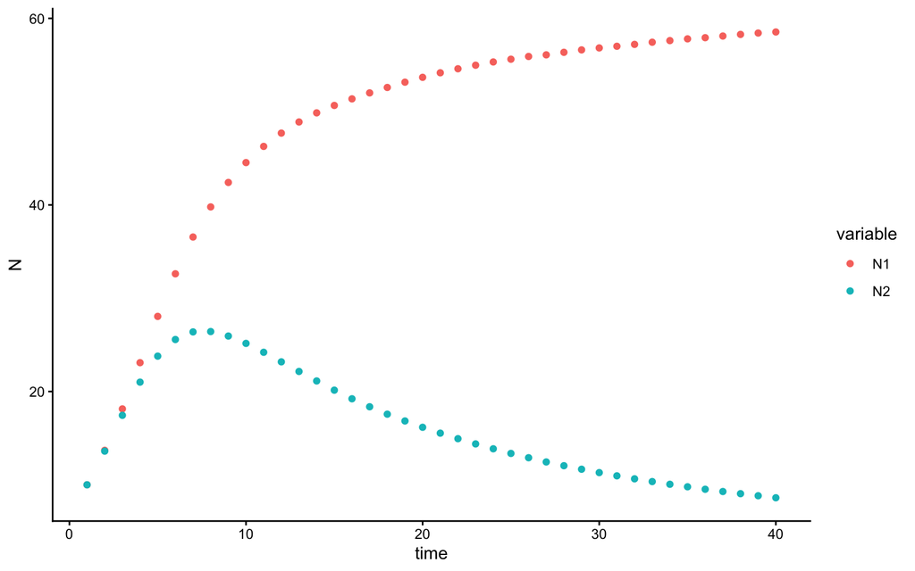

Population size over time for a discrete-time logistic growth model with competition, a changing environment, and trait evolution. Model parameters are $N_{i,0}$ = 10, $\alpha_{ii}$ = 0.01, $\alpha_{12}$ = 0.005, and $\alpha_{21}$ = 0.01.

The overall research goal is to determine the effect of trait evolution for species abundances. We hypothesize that $\lvert x_{t+1} - x_{i,t} \rvert$ is an important driver of species abundances, alongside the environment and species interactions. We plan to fit a statistical model to estimate the impact of $E$, $E^2$, and $\lvert x_{t+1} - x_{i,t} \rvert$ as fixed effects, and time points as a random effect (to estimate species-to-species associations). We first plot the effects of interest as scatter plots with species abundances.

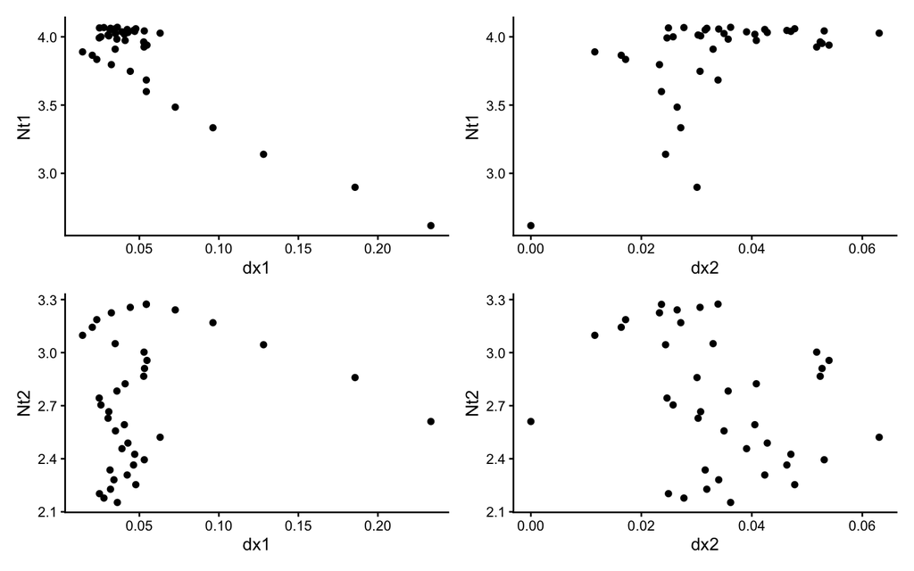

Population size (logarithm) in species 1 and 2 at one time step $N_{i,t+1}$ as a function of change in trait value of Species 1 and Species 2 in the previous time step $|\Delta x_{t,t-1}|$.

We expect that change in traits in Species 1 will have an effect on Species abundances, and we do not expect a strong impact of change in traits in Species 2.

## HMSC statistical model

We now use the species abundances as the response variable in the model, with $E$, $E^2$, and $\lvert x_{t+1} - x_{i,t} \rvert$ as fixed effects, and time points as a random effect (to estimate species-to-species associations). We use the absolute value of the change in trait value from one time point to the next (the total amount of trait change, regardless of direction) as a fixed effect in the HMSC.

```r
dat <- as.data.frame(cbind(log(N), x))
dat$time <- 1:t
df <- data.frame(dat[(2:t), -5])
colnames(df) <- c("Nt1", "Nt2", "xt1", "xt2")
df$dx1 <- abs(dat$x1[2:t] - dat$x1[1:(t - 1)])
df$dx2 <- abs(dat$x2[2:t] - dat$x2[1:(t - 1)])
Y <- as.matrix(cbind(df$Nt1, df$Nt2))
XData <- data.frame(cbind(E[1:(t - 1)], E[1:(t - 1)]^2, abs(dat$x1[2:t] - dat$x1[1:(t -
    1)]), abs(dat$x2[2:t] - dat$x2[1:(t - 1)])))
colnames(XData) <- c("E", "Esq", "dx1", "dx2")
studyDesign = data.frame(sample = as.factor(1:(t - 1)))
rL = HmscRandomLevel(units = studyDesign$sample)
m.7.hmsc = Hmsc(Y = Y, XData = XData, XFormula = ~E + Esq + dx1 + dx2, studyDesign = studyDesign,
    ranLevels = list(sample = rL))
# Bayesian model parameters
nChains <- 2
thin <- 5
samples <- 2000
transient <- 1000 * thin
verbose <- 500 * thin
# sample MCMC
m.7.sample <- sampleMcmc(m.7.hmsc, thin = thin, sample = samples, transient = transient,
    nChains = nChains, verbose = verbose)
```

```
#> Computing chain 1
#> Chain 1, iteration 2500 of 15000 (transient)
#> Chain 1, iteration 5000 of 15000 (transient)
#> Chain 1, iteration 7500 of 15000 (sampling)
#> Chain 1, iteration 10000 of 15000 (sampling)
#> Chain 1, iteration 12500 of 15000 (sampling)
#> Chain 1, iteration 15000 of 15000 (sampling)
#> Computing chain 2
#> Chain 2, iteration 2500 of 15000 (transient)
#> Chain 2, iteration 5000 of 15000 (transient)
#> Chain 2, iteration 7500 of 15000 (sampling)
#> Chain 2, iteration 10000 of 15000 (sampling)
#> Chain 2, iteration 12500 of 15000 (sampling)
#> Chain 2, iteration 15000 of 15000 (sampling)
```

```r
m7.post.hmsc <- convertToCodaObject(m.7.sample)
summary(m7.post.hmsc$Beta)
```

```
#>
#> Iterations = 5005:15000
#> Thinning interval = 5
#> Number of chains = 2
#> Sample size per chain = 2000
#>
#> 1. Empirical mean and standard deviation for each variable,
#>    plus standard error of the mean:
#>
#>                                  Mean     SD  Naive SE Time-series SE
#> B[(Intercept) (C1), sp1 (S1)]  2.8689 0.1496 0.0023656      0.0023658
#> B[E (C2), sp1 (S1)]            1.2923 0.2061 0.0032581      0.0032036
#> B[Esq (C3), sp1 (S1)]         -0.3329 0.0639 0.0010104      0.0009934
#> B[dx1 (C4), sp1 (S1)]         -4.9707 0.2279 0.0036032      0.0035258
#> B[dx2 (C5), sp1 (S1)]          3.4148 0.7182 0.0113554      0.0120523
#> B[(Intercept) (C1), sp2 (S2)]  5.2820 0.1383 0.0021875      0.0022304
#> B[E (C2), sp2 (S2)]           -2.4741 0.1901 0.0030053      0.0030564
#> B[Esq (C3), sp2 (S2)]          0.4666 0.0587 0.0009282      0.0009283
#> B[dx1 (C4), sp2 (S2)]         -4.2172 0.2070 0.0032722      0.0032723
#> B[dx2 (C5), sp2 (S2)]          6.8562 0.6637 0.0104933      0.0098431
#>
#> 2. Quantiles for each variable:
#>
#>                                  2.5%     25%     50%     75%   97.5%
#> B[(Intercept) (C1), sp1 (S1)]  2.5793  2.7686  2.8651  2.9692  3.1651
#> B[E (C2), sp1 (S1)]            0.8843  1.1514  1.2964  1.4294  1.6897
#> B[Esq (C3), sp1 (S1)]         -0.4588 -0.3752 -0.3335 -0.2898 -0.2072
#> B[dx1 (C4), sp1 (S1)]         -5.4259 -5.1174 -4.9671 -4.8207 -4.5436
#> B[dx2 (C5), sp1 (S1)]          2.0188  2.9429  3.4159  3.8974  4.8244
#> B[(Intercept) (C1), sp2 (S2)]  5.0051  5.1913  5.2840  5.3748  5.5555
#> B[E (C2), sp2 (S2)]           -2.8438 -2.6006 -2.4787 -2.3492 -2.0933
#> B[Esq (C3), sp2 (S2)]          0.3496  0.4271  0.4678  0.5051  0.5806
#> B[dx1 (C4), sp2 (S2)]         -4.6360 -4.3514 -4.2158 -4.0857 -3.7977
#> B[dx2 (C5), sp2 (S2)]          5.5166  6.4150  6.8625  7.3011  8.1417
```

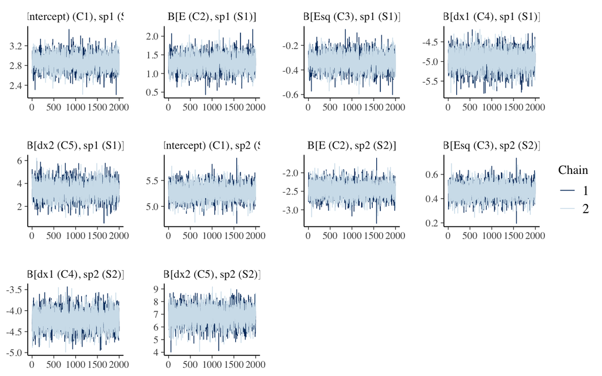

```r
bayesplot::mcmc_trace(m7.post.hmsc$Beta)
```

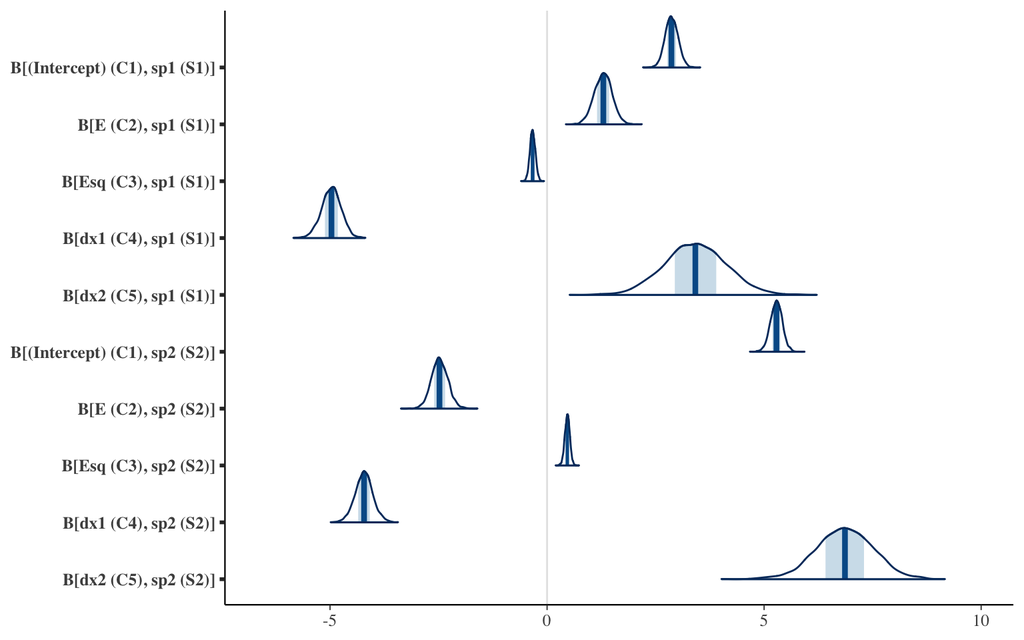

```r
bayesplot::mcmc_areas(m7.post.hmsc$Beta, area_method = c("equal height"))
```

```r
# Bayesian estimates
cbind(summary(m7.post.hmsc$Beta)$statistics[1:10, 1], summary(m7.post.hmsc$Beta)$quantiles[,
    c(1, 5)])
```

```
#>                                                2.5%      97.5%
#> B[(Intercept) (C1), sp1 (S1)]  2.8689310  2.5792716  3.1651279
#> B[E (C2), sp1 (S1)]            1.2923080  0.8842944  1.6897454
#> B[Esq (C3), sp1 (S1)]         -0.3328958 -0.4587869 -0.2072090
#> B[dx1 (C4), sp1 (S1)]         -4.9706907 -5.4258616 -4.5435503
#> B[dx2 (C5), sp1 (S1)]          3.4147944  2.0187669  4.8244125
#> B[(Intercept) (C1), sp2 (S2)]  5.2819918  5.0050821  5.5554974
#> B[E (C2), sp2 (S2)]           -2.4740977 -2.8437664 -2.0932774
#> B[Esq (C3), sp2 (S2)]          0.4665621  0.3495577  0.5805896
#> B[dx1 (C4), sp2 (S2)]         -4.2171885 -4.6359520 -3.7976972
#> B[dx2 (C5), sp2 (S2)]          6.8562285  5.5166052  8.1416526
```

```r
OmegaCor = computeAssociations(m.7.sample)
supportLevel = 0.95
toPlot = ((OmegaCor[[1]]$support > supportLevel) + (OmegaCor[[1]]$support < (1 -
    supportLevel)) > 0) * OmegaCor[[1]]$mean
corrplot::corrplot(toPlot, method = "color", col = colorRampPalette(c("blue", "white",
    "red"))(200), title = paste("random effect level:", m.7.sample$rLNames[1]), mar = c(0,
    0, 1, 0))
```

[output not shown]

```r
OmegaCor
```

```
#> [[1]]
#> [[1]]$mean
#>            sp1        sp2
#> sp1  1.0000000 -0.4103122
#> sp2 -0.4103122  1.0000000
#>
#> [[1]]$support
#>         sp1     sp2
#> sp1 1.00000 0.24775
#> sp2 0.24775 1.00000
```

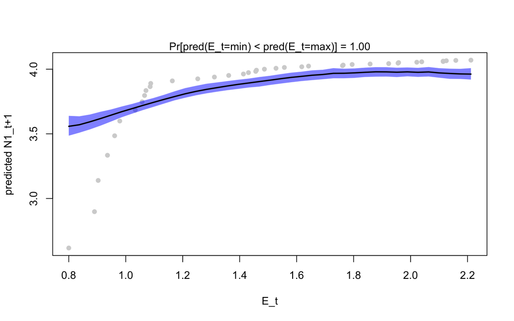

```r
Gradient <- constructGradient(m.7.sample, focalVariable = "E", non.focalVariables = list(Esq = list(2),
    dx1 = list(1), dx2 = list(1)), ngrid = 39)
# Esq is manually constructed as gradient-produced E^2
Gradient$XDataNew$Esq <- Gradient$XDataNew$E^2
predY <- predict(m.7.sample, XData = Gradient$XDataNew, expected = TRUE)
a <- plotGradient(m.7.sample, Gradient, pred = predY, showData = T, measure = "Y",
    index = 1, main = "", xlab = "E_t", ylab = "predicted N1_t+1")
```

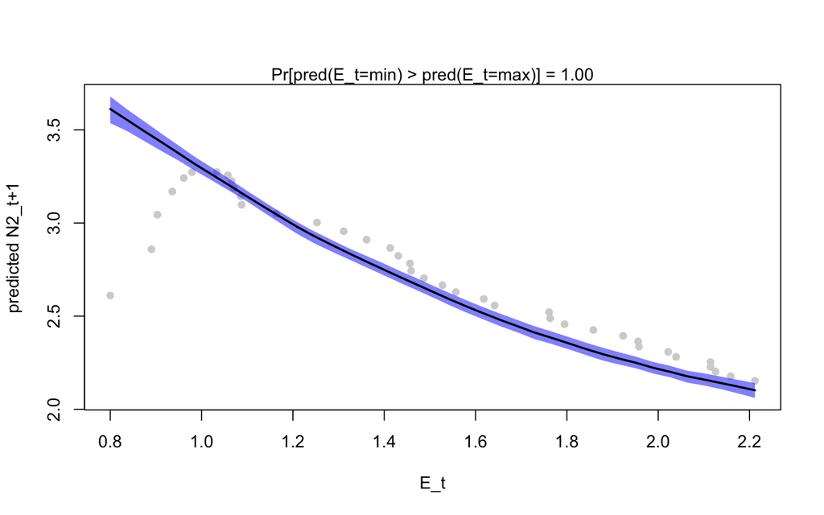

```r
b <- plotGradient(m.7.sample, Gradient, pred = predY, showData = T, measure = "Y",
    index = 2, main = "", xlab = "E_t", ylab = "predicted N2_t+1")
```

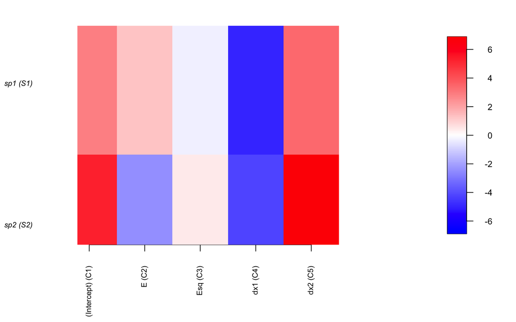

```r
postBeta = getPostEstimate(m.7.sample, parName = "Beta")
plotBeta(m.7.sample, post = postBeta, param = "Mean", supportLevel = 0.95)
```

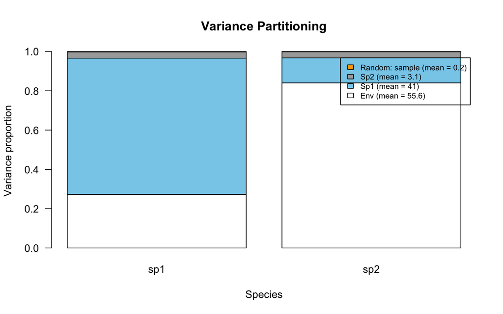

```r
VP <- computeVariancePartitioning(m.7.sample, group = c(1, 1, 1, 2, 3), groupnames = c("Env",
    "Sp1", "Sp2"))
plotVariancePartitioning(m.7.sample, VP, cols = c("white", "skyblue", "darkgrey",
    "orange"), args.legend = list(cex = 0.75, bg = "transparent"))
```

We can also look at a gradient plot for the effect of evolution in Species 1 for abundance in Species 1 and Species 2.

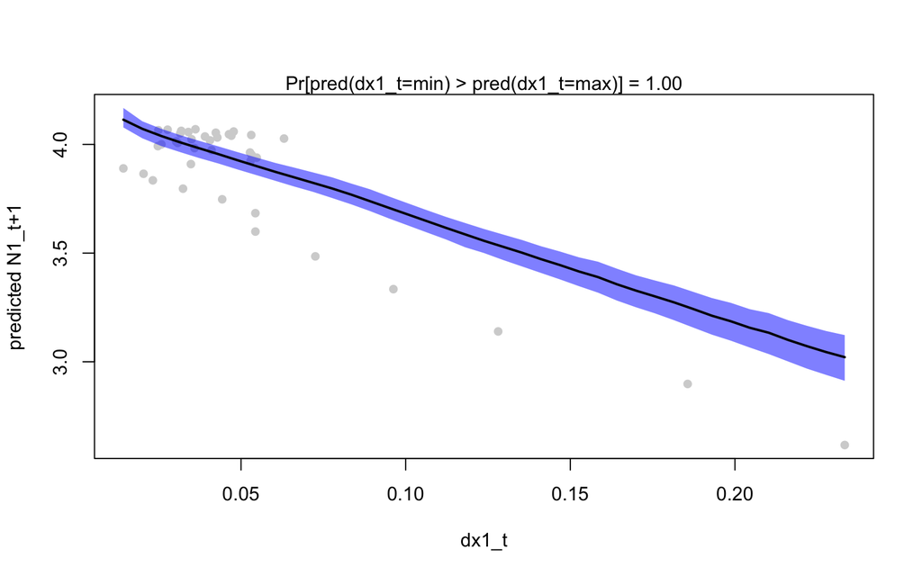

```r
Gradient <- constructGradient(m.7.sample, focalVariable = "dx1", non.focalVariables = list(E = list(1),
    Esq = list(2), dx2 = list(1)), ngrid = 39)
Gradient$XDataNew$Esq <- Gradient$XDataNew$E^2
predY <- predict(m.7.sample, XData = Gradient$XDataNew, expected = TRUE)
a <- plotGradient(m.7.sample, Gradient, pred = predY, showData = T, measure = "Y",
    index = 1, main = "", xlab = "dx1_t", ylab = "predicted N1_t+1")
```

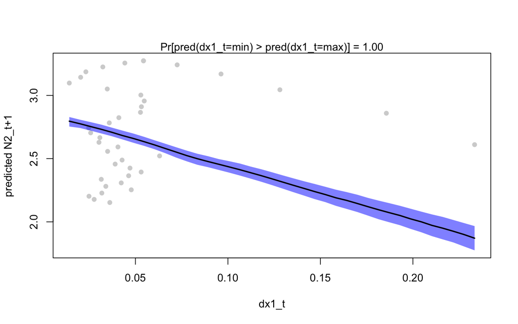

```r
b <- plotGradient(m.7.sample, Gradient, pred = predY, showData = T, measure = "Y",
    index = 2, main = "", xlab = "dx1_t", ylab = "predicted N2_t+1")
```

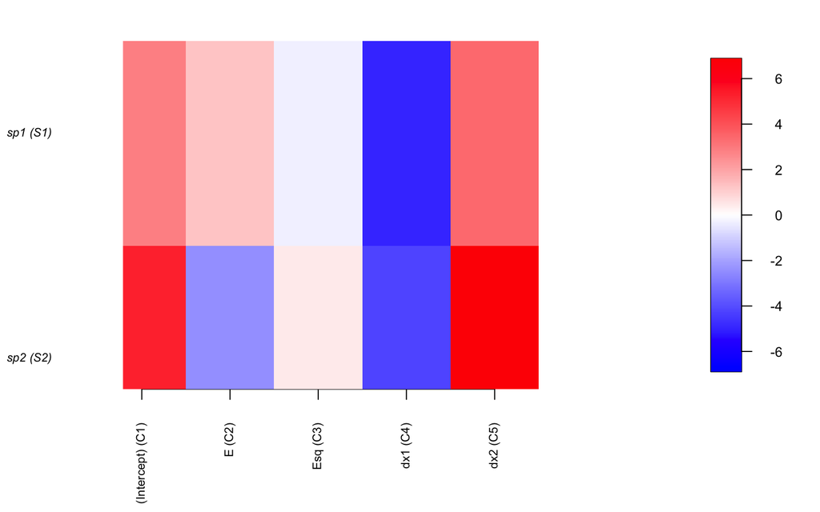

```r
postBeta = getPostEstimate(m.7.sample, parName = "Beta")
plotBeta(m.7.sample, post = postBeta, param = "Mean", supportLevel = 0.95)
```

We repeat this plot for the effect of evolution in Species 2 for abundance in Species 1 and Species 2.

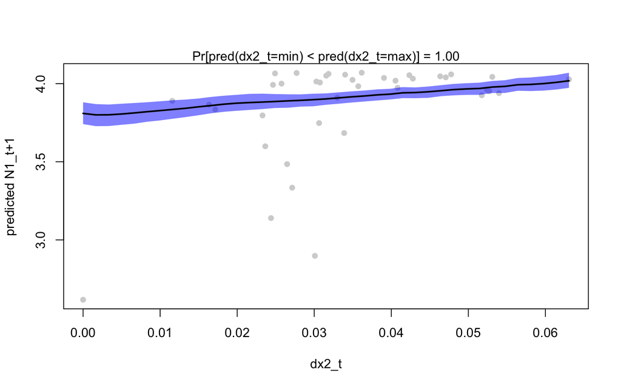

```r
Gradient <- constructGradient(m.7.sample, focalVariable = "dx2", non.focalVariables = list(E = list(1),
    Esq = list(2), dx1 = list(1)), ngrid = 39)
Gradient$XDataNew$Esq <- Gradient$XDataNew$E^2
predY <- predict(m.7.sample, XData = Gradient$XDataNew, expected = TRUE)
a <- plotGradient(m.7.sample, Gradient, pred = predY, showData = T, measure = "Y",
    index = 1, main = "", xlab = "dx2_t", ylab = "predicted N1_t+1")
```

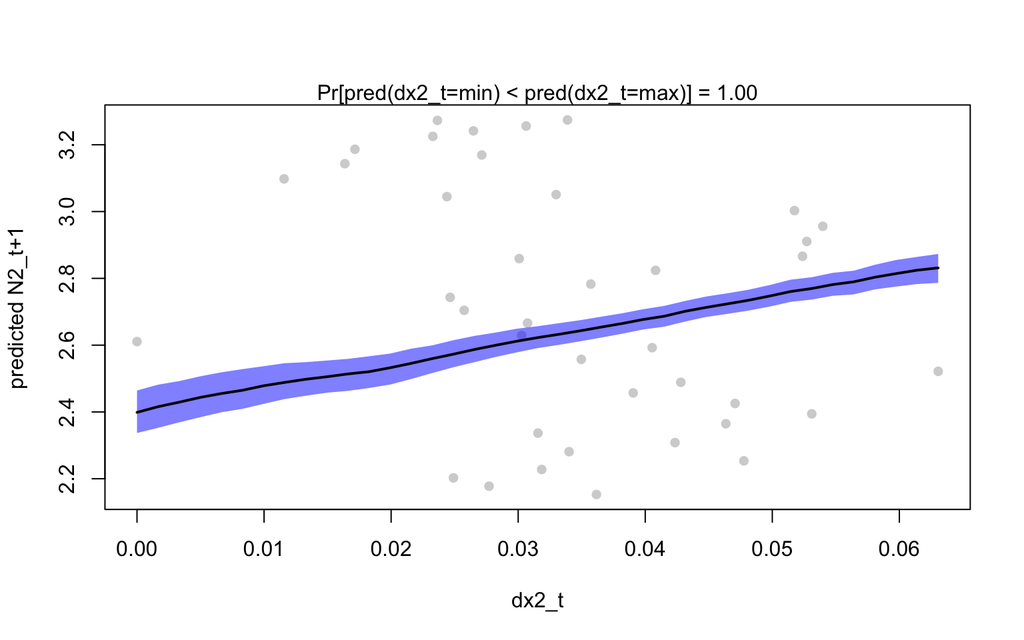

```r
b <- plotGradient(m.7.sample, Gradient, pred = predY, showData = T, measure = "Y",
    index = 2, main = "", xlab = "dx2_t", ylab = "predicted N2_t+1")
```

## Conclusions

The analysis indicates that we can successfully use the HMSC analysis to partition drivers of species abundances that include evolving traits. We see that change in Species 1 trait is a strong driver of abundances in Species1 and 2, and that trait change in Species 2 has a weaker impact. This aligns well with the observed simulation results.

Though some of the main effect coefficients aren’t well reflected in the data, we recall the model has strong predictive power when the elements are combined, with high predictive power to the observed data.

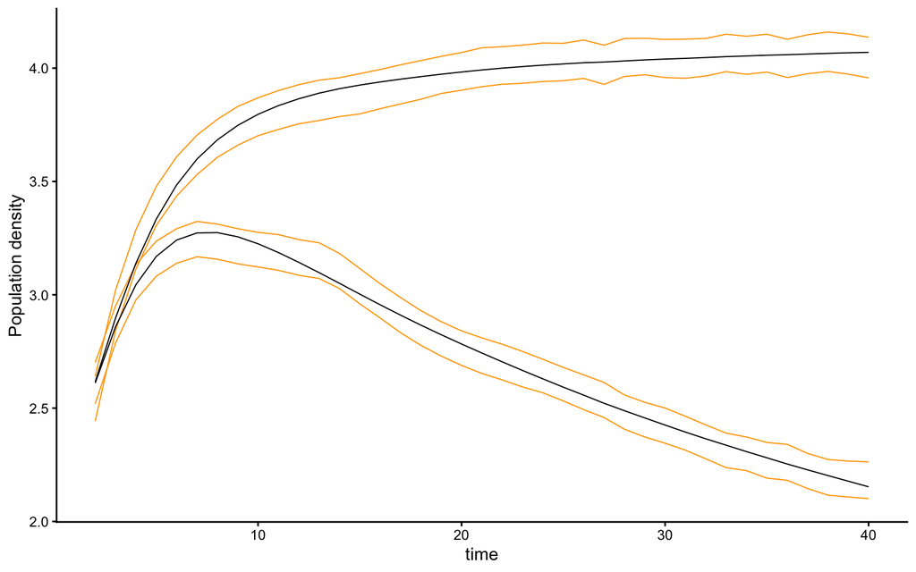

Observed (black) and HMSC model-predicted population size (logarithm, orange) for Species 1 and Species 2, using environment $E_t$ and change in trait value $|\Delta x|$ as a fixed effect predictor and specifying temporal random effects to capture the species interactions.

However, we can see the coefficients are less informative for inference. It is specific to this set of simulation conditions that the degree of evolution occurs at the beginning of the simulation, when the species is more mal-adapted. To better consider how trait evolution drives changes in population size, we use this change as the response variable Y in the predictive model.

```r
# Plot simulation: ggplot
dat <- as.data.frame(cbind(log(N$N1), log(N$N2), x$x1, x$x2))
colnames(dat) <- c("N1", "N2", "x1", "x2")
dat$time <- 1:t
df <- data.frame(cbind(dat$N1[2:t], dat$N2[2:t], dat$x1[2:t], dat$x2[2:t]))
colnames(df) <- c("Nt1", "Nt2", "xt1", "xt2")
df$dN1 <- abs(dat$N1[2:t] - dat$N1[1:(t - 1)])
df$dN2 <- abs(dat$N2[2:t] - dat$N2[1:(t - 1)])
df$dx1 <- abs(dat$x1[2:t] - dat$x1[1:(t - 1)])
df$dx2 <- abs(dat$x2[2:t] - dat$x2[1:(t - 1)])
# prepare data in HMSC format
Y <- as.matrix(cbind(df$dN1, df$dN2))
XData <- data.frame(cbind(E[1:(t - 1)], E[1:(t - 1)]^2, abs(dat$x1[2:t] - dat$x1[1:(t -
    1)]), abs(dat$x2[2:t] - dat$x2[1:(t - 1)])))
colnames(XData) <- c("E", "Esq", "dx1", "dx2")
studyDesign = data.frame(sample = as.factor(1:(t - 1)))
rL = HmscRandomLevel(units = studyDesign$sample)
m.8.hmsc = Hmsc(Y = Y, XData = XData, XFormula = ~E + Esq + dx1 + dx2, studyDesign = studyDesign,
    ranLevels = list(sample = rL))
# Bayesian model parameters
nChains <- 2
thin <- 5
samples <- 2000
transient <- 1000 * thin
verbose <- 500 * thin
# sample MCMC
m.8.sample <- sampleMcmc(m.8.hmsc, thin = thin, sample = samples, transient = transient,
    nChains = nChains, verbose = verbose)
```

```
#> Computing chain 1
#> Chain 1, iteration 2500 of 15000 (transient)
#> Chain 1, iteration 5000 of 15000 (transient)
#> Chain 1, iteration 7500 of 15000 (sampling)
#> Chain 1, iteration 10000 of 15000 (sampling)
#> Chain 1, iteration 12500 of 15000 (sampling)
#> Chain 1, iteration 15000 of 15000 (sampling)
#> Computing chain 2
#> Chain 2, iteration 2500 of 15000 (transient)
#> Chain 2, iteration 5000 of 15000 (transient)
#> Chain 2, iteration 7500 of 15000 (sampling)
#> Chain 2, iteration 10000 of 15000 (sampling)
#> Chain 2, iteration 12500 of 15000 (sampling)
#> Chain 2, iteration 15000 of 15000 (sampling)
```

```r
m8.post.hmsc <- convertToCodaObject(m.8.sample)
summary(m8.post.hmsc$Beta)
```

```
#>
#> Iterations = 5005:15000
#> Thinning interval = 5
#> Number of chains = 2
#> Sample size per chain = 2000
#>
#> 1. Empirical mean and standard deviation for each variable,
#>    plus standard error of the mean:
#>
#>                                   Mean      SD  Naive SE Time-series SE
#> B[(Intercept) (C1), sp1 (S1)]  0.34742 0.11089 0.0017533      0.0017037
#> B[E (C2), sp1 (S1)]           -0.41415 0.15298 0.0024189      0.0024189
#> B[Esq (C3), sp1 (S1)]          0.11514 0.04751 0.0007512      0.0007512
#> B[dx1 (C4), sp1 (S1)]          1.15744 0.17136 0.0027095      0.0027600
#> B[dx2 (C5), sp1 (S1)]         -0.63291 0.53307 0.0084285      0.0086952
#> B[(Intercept) (C1), sp2 (S2)] -0.10279 0.10751 0.0016999      0.0017953
#> B[E (C2), sp2 (S2)]            0.17311 0.14811 0.0023418      0.0024753
#> B[Esq (C3), sp2 (S2)]         -0.05427 0.04584 0.0007247      0.0007349
#> B[dx1 (C4), sp2 (S2)]          1.39762 0.16062 0.0025396      0.0025399
#> B[dx2 (C5), sp2 (S2)]         -1.28696 0.51197 0.0080949      0.0082622
#>
#> 2. Quantiles for each variable:
#>
#>                                   2.5%      25%      50%      75%    97.5%
#> B[(Intercept) (C1), sp1 (S1)]  0.12485  0.27474  0.34921  0.42026  0.56453
#> B[E (C2), sp1 (S1)]           -0.72011 -0.51493 -0.41532 -0.31373 -0.10810
#> B[Esq (C3), sp1 (S1)]          0.02018  0.08448  0.11563  0.14650  0.20978
#> B[dx1 (C4), sp1 (S1)]          0.82494  1.04445  1.15561  1.27024  1.49420
#> B[dx2 (C5), sp1 (S1)]         -1.67933 -0.99984 -0.62392 -0.27481  0.43213
#> B[(Intercept) (C1), sp2 (S2)] -0.32034 -0.17342 -0.10219 -0.03317  0.11076
#> B[E (C2), sp2 (S2)]           -0.11713  0.07718  0.17172  0.26905  0.47630
#> B[Esq (C3), sp2 (S2)]         -0.14704 -0.08439 -0.05379 -0.02421  0.03474
#> B[dx1 (C4), sp2 (S2)]          1.06702  1.29512  1.39933  1.50135  1.70843
#> B[dx2 (C5), sp2 (S2)]         -2.28991 -1.63008 -1.28566 -0.94407 -0.27855
```

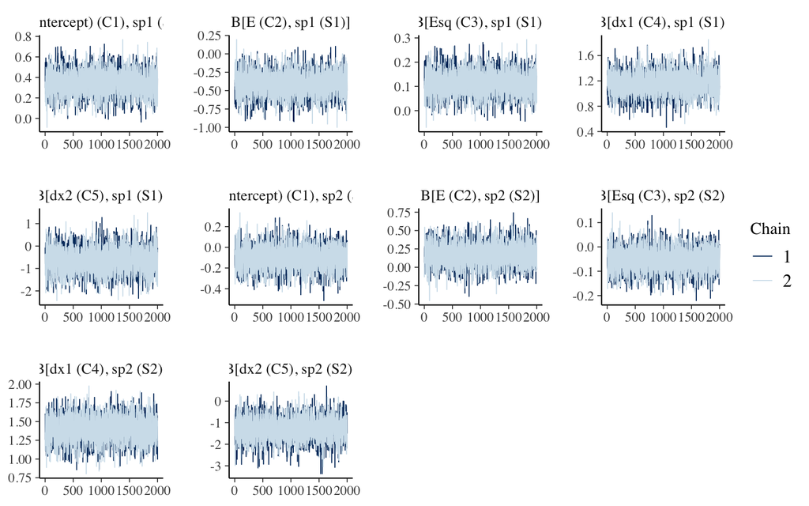

```r
bayesplot::mcmc_trace(m8.post.hmsc$Beta)
```

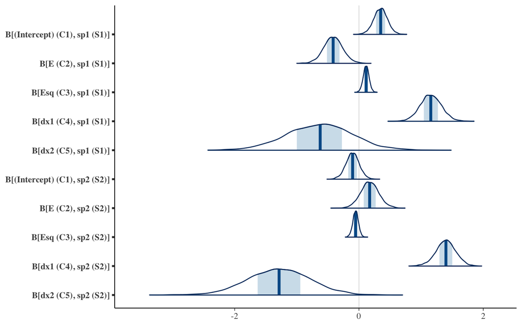

```r
bayesplot::mcmc_areas(m8.post.hmsc$Beta, area_method = c("equal height"))
```

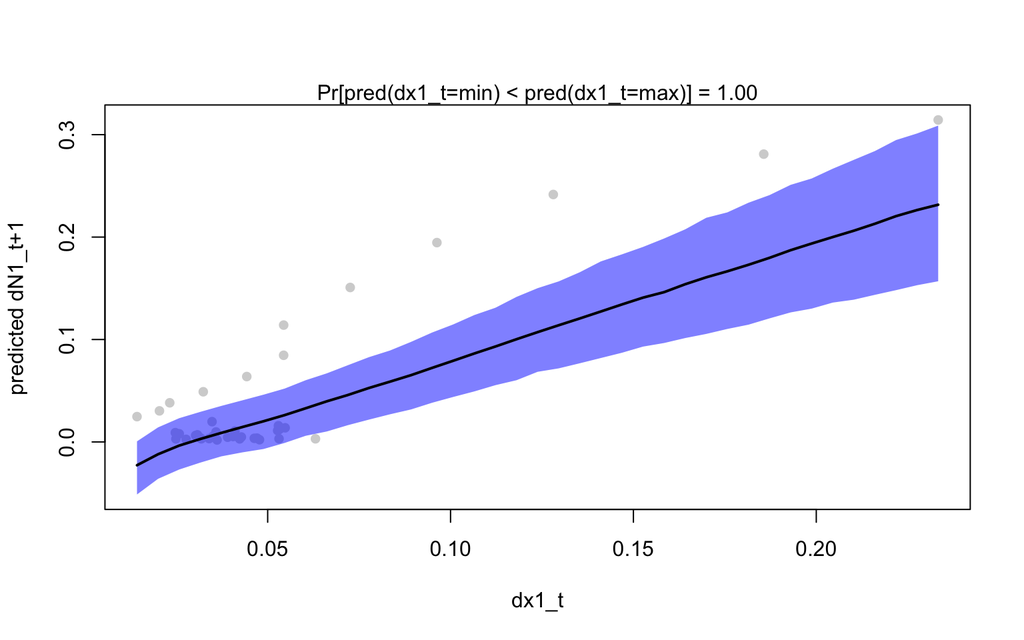

```r
Gradient <- constructGradient(m.8.sample, focalVariable = "dx1", non.focalVariables = list(E = list(1),
    Esq = list(2), dx2 = list(1)), ngrid = 39)
Gradient$XDataNew$Esq <- Gradient$XDataNew$E^2
predY <- predict(m.8.sample, XData = Gradient$XDataNew, expected = TRUE)
a <- plotGradient(m.8.sample, Gradient, pred = predY, showData = T, measure = "Y",
    index = 1, main = "", xlab = "dx1_t", ylab = "predicted dN1_t+1")
```

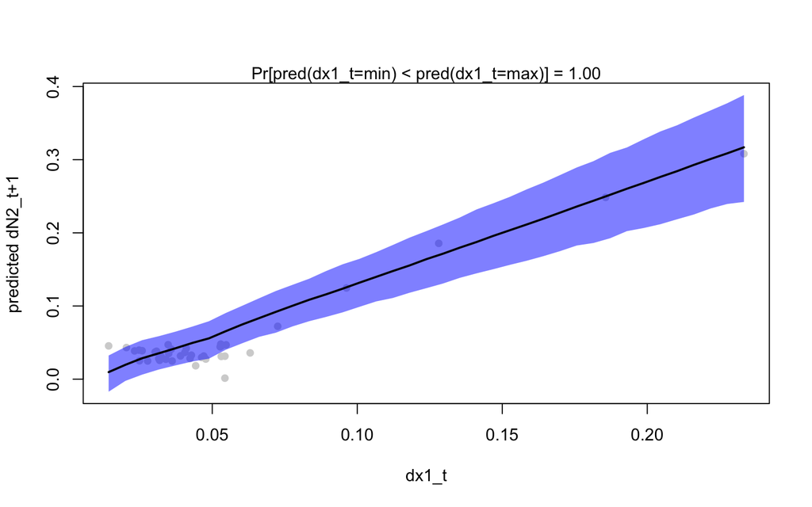

```r
b <- plotGradient(m.8.sample, Gradient, pred = predY, showData = T, measure = "Y",
    index = 2, main = "", xlab = "dx1_t", ylab = "predicted dN2_t+1")
```

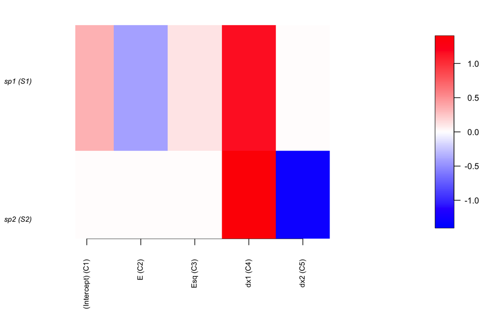

```r
postBeta = getPostEstimate(m.8.sample, parName = "Beta")
plotBeta(m.8.sample, post = postBeta, param = "Mean", supportLevel = 0.95)
```

We repeat this plot for the effect of evolution in Species 2 for abundance in Species 1 and Species 2.

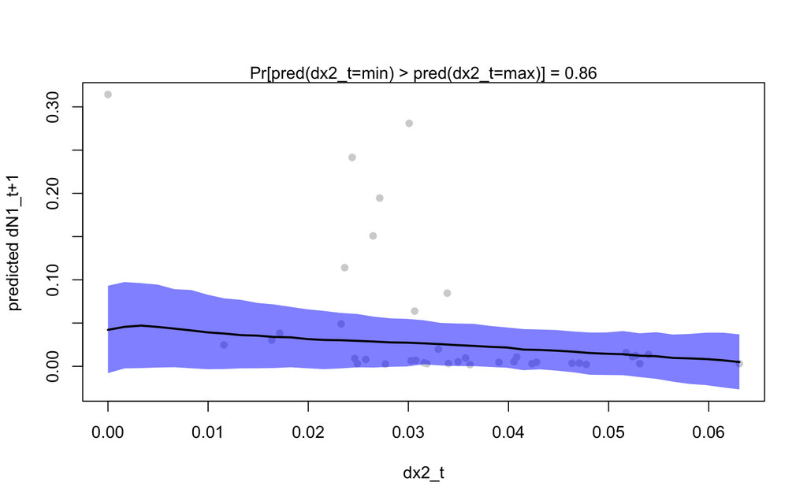

```r
Gradient <- constructGradient(m.8.sample, focalVariable = "dx2", non.focalVariables = list(E = list(1),
    Esq = list(2), dx1 = list(1)), ngrid = 39)
Gradient$XDataNew$Esq <- Gradient$XDataNew$E^2
predY <- predict(m.8.sample, XData = Gradient$XDataNew, expected = TRUE)
a <- plotGradient(m.8.sample, Gradient, pred = predY, showData = T, measure = "Y",
    index = 1, main = "", xlab = "dx2_t", ylab = "predicted dN1_t+1")
```

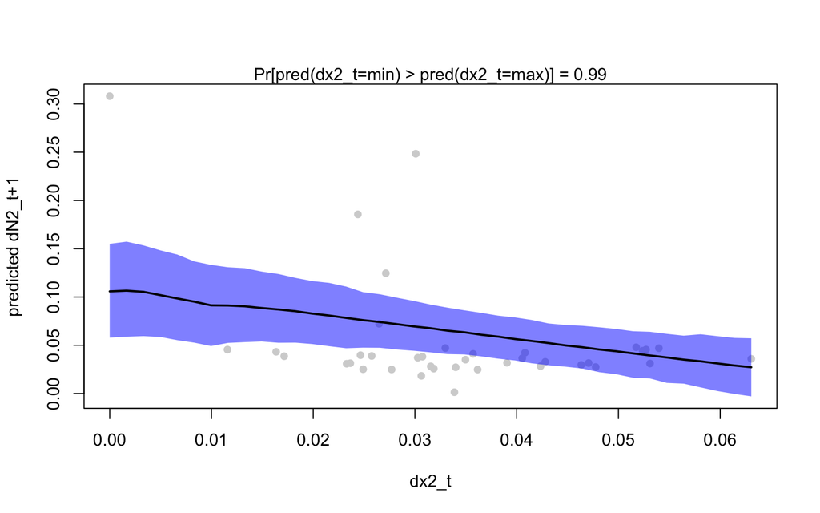

```r
b <- plotGradient(m.8.sample, Gradient, pred = predY, showData = T, measure = "Y",
    index = 2, main = "", xlab = "dx2_t", ylab = "predicted dN2_t+1")
```

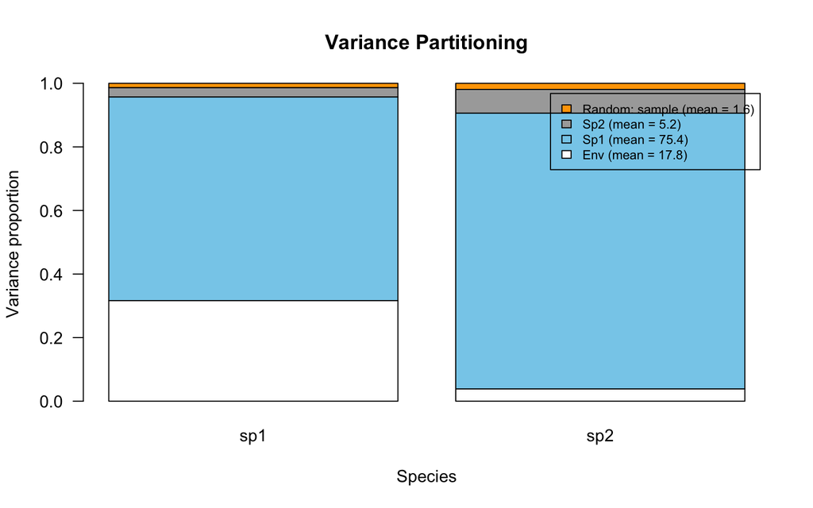

```r
VP <- computeVariancePartitioning(m.8.sample, group = c(1, 1, 1, 2, 3), groupnames = c("Env",
    "Sp1", "Sp2"))
plotVariancePartitioning(m.8.sample, VP, cols = c("white", "skyblue", "darkgrey",
    "orange"), args.legend = list(cex = 0.75, bg = "transparent"))
```

Here we can see that trait evolution in Species 1 had a strong positive relationship with the *change* in population size for both species. Trait evolution in Species 2 had much less of an effect.

# Model F: Species growth, competition, environmental change, and trait evolution in a spatially structured environment

## Correlated dynamics in multiple patches

We now consider that trait evolution can occur, with an impact on the species growth rate / fitness in the context of the environment. We also add a final consideration to the model, the existence of multiple sites with correlation structure in the variance of species abundances. We consider this in our simulation by adding multiple (10) sites, with low vs. high spatial covariance in abundances, depending on distance between sites. We then include spatial random effects in the HMSC statistical model, where species associations are considered as a function of distance between sites.

## Population dynamics simulation

We use the same example as above, but now with 10 sites. To illustrate how HMSC can estimate the impacts of distance-dependent spatial covariance, we duplicate the population time series obtained in the example above, but we add in site variance and among-site covariance.

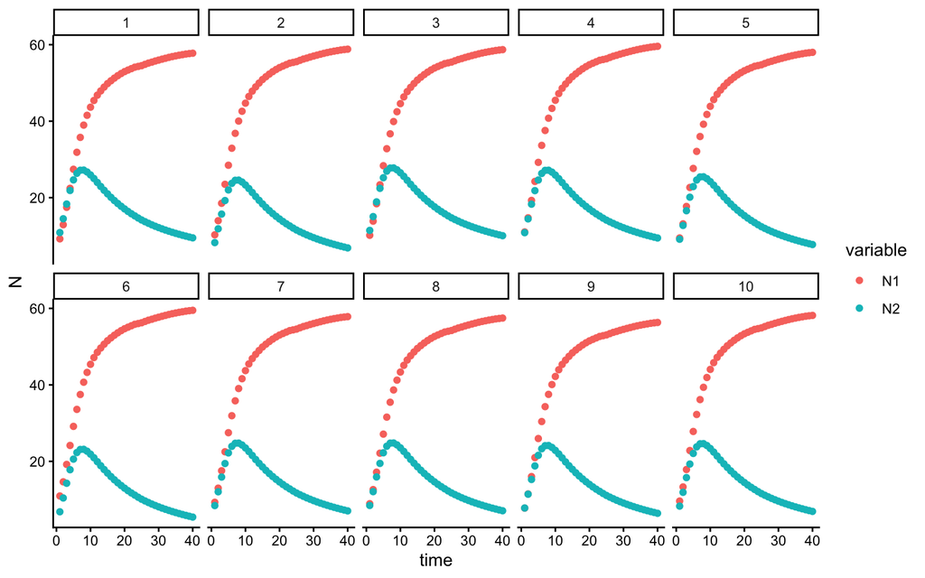

Population size over time for a discrete-time logistic growth model with competition, a changing environment, and trait evolution. Values are shown at 10 sites, with site covariance in species abundances depending on spatial distance.

```r
# Case 1: Weaker interactions, stronger environment Simulate initial species
# population growth with environment fluctuations
N0 <- c(10, 10)
E.0 <- 0.8
x.0 <- c(0.1, 0.8)
alpha.11 <- 0.01
alpha.22 <- 0.01
alpha.12 <- 0.005
alpha.21 <- 0.01
alpha <- matrix(c(alpha.11, alpha.21, alpha.12, alpha.22), nrow = 2, byrow = FALSE)
P <- 1
w <- 2
Wmax <- 2
h2 <- 1
k <- (w + (1 - h2) * P)/(P + w)
j <- 10
# Simulation of model for t time steps, i sites
xycoords = matrix(runif(2 * j), ncol = 2)
rownames(xycoords) <- 1:j
t <- 40
N <- array(NA, dim = c(j * t, length(N0)))
N <- as.data.frame(N)
colnames(N) <- paste0("N", 1:length(N0))
x <- array(NA, dim = c(j * t, length(N0)))
x <- as.data.frame(x)
colnames(x) <- paste0("x", 1:length(N0))
r <- array(NA, dim = c(j * t, length(N0)))
r <- as.data.frame(r)
colnames(r) <- paste0("r", 1:length(N0))
N[1:j, ] <- rep(N0, each = j)
E <- rep(NA, t)
E[1] <- E.0
x[1:j, ] <- rep(x.0, each = j)
What <- Wmax * sqrt(w/(P + w))
r0 <- as.numeric(What * exp((-(((w + (1 - h2) * P)/(P + w)) * (E[1] - x[1, ]))^2)/(2 *
    (P + w))))
r[1:j, ] <- rep(r0, each = j)
# Keep track of site and time
study <- array(NA, dim = c(j * t, 3))
study <- as.data.frame(study)
colnames(study) <- c("obs", "site", "time")
study$obs <- 1:dim(study)[1]
study$site <- rep(1:j, times = t)
study$time <- rep(1:t, each = j)

for (i in 2:t) {
    for (z in 1:j) {
        res <- disc_LV_evol(N0 = N[study$site == z & study$time == i - 1, ], alpha = alpha,
            E = E[i - 1], x = x[study$site == z & study$time == i - 1, ], P = P,
            w = w, Wmax = Wmax, h2 = h2)
        N[study$site == z & study$time == i, ] <- res$Nt1
        r[study$site == z & study$time == i, ] <- res$r
        # trait change
        d <- E[i - 1] - x[study$site == z & study$time == i - 1, ]
        d1 <- k * d
        x[study$site == z & study$time == i, ] <- E[i - 1] - d1
    }
    # environmental change
    E[i] <- E[i - 1] + abs(rnorm(1, 0, 0.05))
}
# site-level random effect
sigma <- 0
sigma.spatial <- 2
alpha.spatial <- 0.5
Sigma = sigma.spatial^2 * exp(-as.matrix(dist(xycoords))/alpha.spatial)
# draw from covariance matrix
a = mvrnorm(mu = rep(0, j), Sigma = Sigma)
for (i in 1:t) {
    N$N1[study$time == i] <- N$N1[study$time == i] + a
}
a = mvrnorm(mu = rep(0, j), Sigma = Sigma)
for (i in 1:t) {
    N$N2[study$time == i] <- N$N2[study$time == i] + a
}
```

## HMSC statistical model

We now fit a spatial random effect, and add that to the HMSC model.

```r
# prepare data in HMSC format
dat <- as.data.frame(cbind(log(N), x))
dat$time <- study$time
df <- data.frame(cbind(dat$N1[dat$time != 1], dat$N2[dat$time != 1], dat$x1[dat$time !=
    1], dat$x2[dat$time != 1]))
colnames(df) <- c("Nt1", "Nt2", "xt1", "xt2")
Y <- as.matrix(cbind(df$Nt1, df$Nt2))
XData <- data.frame(E = rep(E[1:(t - 1)], each = j))
XData$Esq <- XData$E^2
XData$dx1 <- abs(dat$x1[dat$time != 1] - dat$x1[dat$time != t])
XData$dx2 <- abs(dat$x2[dat$time != 1] - dat$x2[dat$time != t])
# Update study design to include spatial random effects
samp1 <- 1:(j * t)
samp1 <- as.data.frame(samp1)
samp1 <- subset(samp1, samp1 > 10)
rownames(XData) <- row.names(samp1)
studyDesign = data.frame(sample = 1:(j * (t - 1)), site = study$site[study$time >
    1])
studyDesign$sample <- as.factor(studyDesign$sample)
studyDesign$site <- as.factor(studyDesign$site)
rL.spatial = HmscRandomLevel(sData = xycoords)
rL.sample = HmscRandomLevel(units = studyDesign$sample)
# Fit HMSC model
m.9.hmsc = Hmsc(Y = Y, XData = XData, XFormula = ~E + Esq + dx1 + dx2, studyDesign = studyDesign,
    ranLevels = list(sample = rL.sample, site = rL.spatial))
# Bayesian model parameters
nChains <- 2
thin <- 5
samples <- 2000
transient <- 1000 * thin
verbose <- 500 * thin
# sample MCMC
m.9.sample <- sampleMcmc(m.9.hmsc, thin = thin, sample = samples, transient = transient,
    nChains = nChains, verbose = verbose)
```

```
#> Computing chain 1
#> Chain 1, iteration 2500 of 15000 (transient)
#> Chain 1, iteration 5000 of 15000 (transient)
#> Chain 1, iteration 7500 of 15000 (sampling)
#> Chain 1, iteration 10000 of 15000 (sampling)
#> Chain 1, iteration 12500 of 15000 (sampling)
#> Chain 1, iteration 15000 of 15000 (sampling)
#> Computing chain 2
#> Chain 2, iteration 2500 of 15000 (transient)
#> Chain 2, iteration 5000 of 15000 (transient)
#> Chain 2, iteration 7500 of 15000 (sampling)
#> Chain 2, iteration 10000 of 15000 (sampling)
#> Chain 2, iteration 12500 of 15000 (sampling)
#> Chain 2, iteration 15000 of 15000 (sampling)
```

```r
m9.post.hmsc <- convertToCodaObject(m.9.sample)
summary(m9.post.hmsc$Beta)
```

```
#>
#> Iterations = 5005:15000
#> Thinning interval = 5
#> Number of chains = 2
#> Sample size per chain = 2000
#>
#> 1. Empirical mean and standard deviation for each variable,
#>    plus standard error of the mean:
#>
#>                                  Mean       SD  Naive SE Time-series SE
#> B[(Intercept) (C1), sp1 (S1)]  2.9085 0.032859 0.0005196      0.0005627
#> B[E (C2), sp1 (S1)]            1.1219 0.029172 0.0004612      0.0004613
#> B[Esq (C3), sp1 (S1)]         -0.2641 0.008295 0.0001312      0.0001312
#> B[dx1 (C4), sp1 (S1)]         -4.6591 0.046911 0.0007417      0.0007796
#> B[dx2 (C5), sp1 (S1)]          3.6254 0.092881 0.0014686      0.0014683
#> B[(Intercept) (C1), sp2 (S2)]  4.6651 0.135837 0.0021478      0.0021471
#> B[E (C2), sp2 (S2)]           -1.5757 0.066656 0.0010539      0.0010540
#> B[Esq (C3), sp2 (S2)]          0.1973 0.018959 0.0002998      0.0002998
#> B[dx1 (C4), sp2 (S2)]         -4.4298 0.107595 0.0017012      0.0017507
#> B[dx2 (C5), sp2 (S2)]          6.9814 0.214914 0.0033981      0.0033982
#>
#> 2. Quantiles for each variable:
#>
#>                                  2.5%     25%     50%     75%   97.5%
#> B[(Intercept) (C1), sp1 (S1)]  2.8451  2.8875  2.9082  2.9285  2.9748
#> B[E (C2), sp1 (S1)]            1.0642  1.1021  1.1217  1.1418  1.1808
#> B[Esq (C3), sp1 (S1)]         -0.2809 -0.2697 -0.2640 -0.2584 -0.2476
#> B[dx1 (C4), sp1 (S1)]         -4.7497 -4.6906 -4.6598 -4.6271 -4.5682
#> B[dx2 (C5), sp1 (S1)]          3.4417  3.5632  3.6254  3.6886  3.8078
#> B[(Intercept) (C1), sp2 (S2)]  4.3919  4.5849  4.6627  4.7444  4.9437
#> B[E (C2), sp2 (S2)]           -1.7087 -1.6199 -1.5752 -1.5300 -1.4445
#> B[Esq (C3), sp2 (S2)]          0.1599  0.1845  0.1974  0.2100  0.2347
#> B[dx1 (C4), sp2 (S2)]         -4.6399 -4.5028 -4.4302 -4.3572 -4.2208
#> B[dx2 (C5), sp2 (S2)]          6.5591  6.8354  6.9856  7.1269  7.4019
```

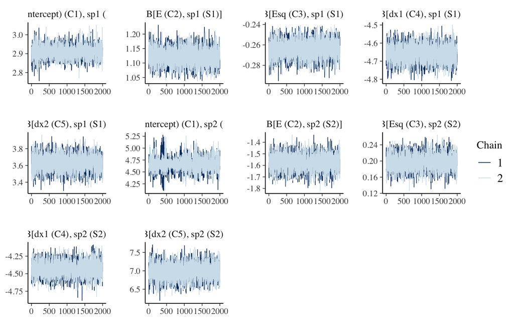

```r
bayesplot::mcmc_trace(m9.post.hmsc$Beta)
```

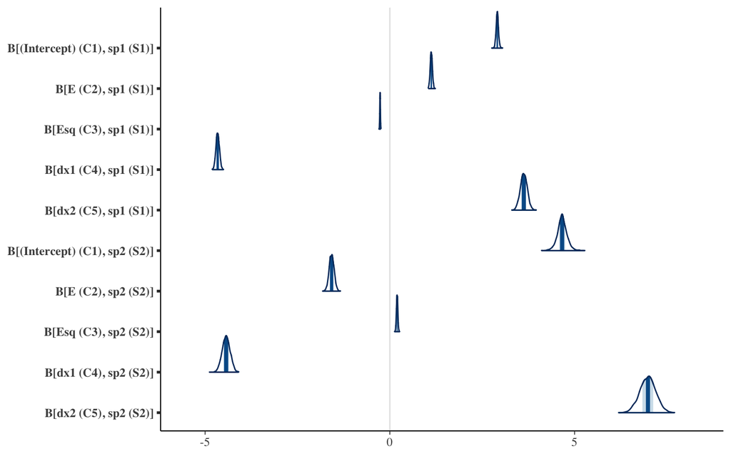

```r
bayesplot::mcmc_areas(m9.post.hmsc$Beta, area_method = c("equal height"))
```

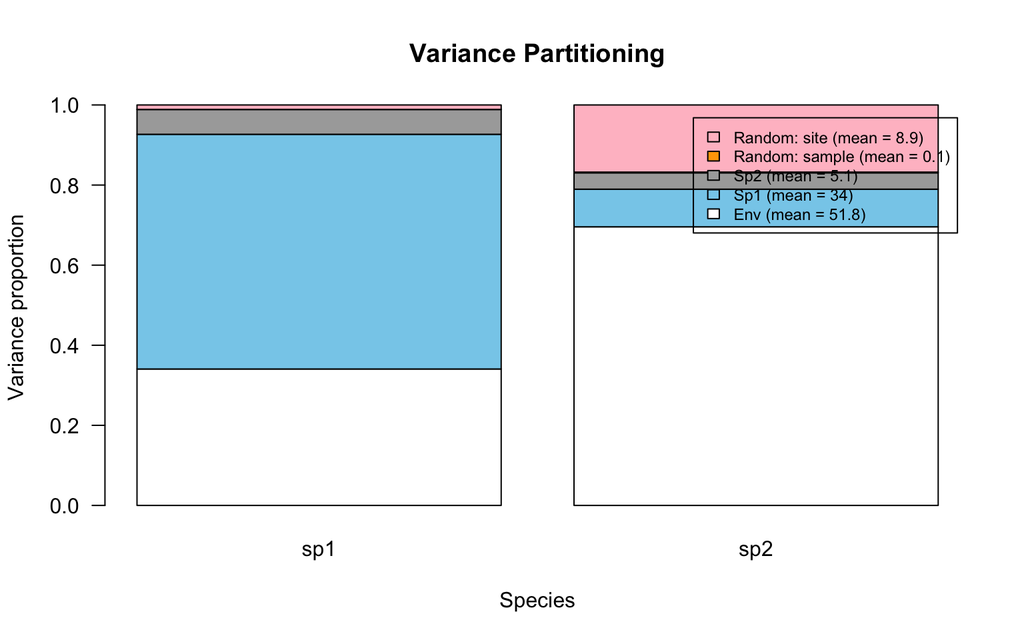

```r
VP <- computeVariancePartitioning(m.9.sample, group = c(1, 1, 1, 2, 3), groupnames = c("Env",
    "Sp1", "Sp2"))
plotVariancePartitioning(m.9.sample, VP, cols = c("white", "skyblue", "darkgrey",
    "orange", "pink"), args.legend = list(cex = 0.75, bg = "transparent"))
```

```r
OmegaCor = computeAssociations(m.9.sample)
supportLevel = 0.95
toPlot = ((OmegaCor[[1]]$support > supportLevel) + (OmegaCor[[1]]$support < (1 -
    supportLevel)) > 0) * OmegaCor[[1]]$mean
corrplot::corrplot(toPlot, method = "color", col = colorRampPalette(c("blue", "white",
    "red"))(200), title = paste("random effect level:", m.9.sample$rLNames[1]), mar = c(0,
    0, 1, 0))
```

```r
OmegaCor
```

```
#> [[1]]
#> [[1]]$mean
#>            sp1        sp2
#> sp1 1.00000000 0.05781371
#> sp2 0.05781371 1.00000000
#>
#> [[1]]$support
#>         sp1     sp2
#> sp1 1.00000 0.54275
#> sp2 0.54275 1.00000
#>
#>
#> [[2]]
#> [[2]]$mean
#>           sp1       sp2
#> sp1 1.0000000 0.1083981
#> sp2 0.1083981 1.0000000
#>
#> [[2]]$support
#>         sp1     sp2
#> sp1 1.00000 0.60525
#> sp2 0.60525 1.00000
```

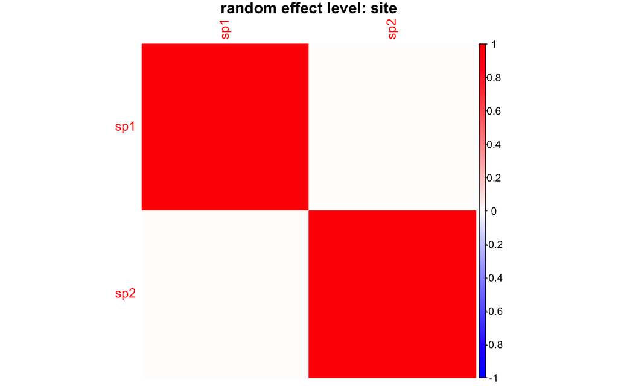

```r
toPlot = ((OmegaCor[[2]]$support > supportLevel) + (OmegaCor[[2]]$support < (1 -
    supportLevel)) > 0) * OmegaCor[[2]]$mean
corrplot::corrplot(toPlot, method = "color", col = colorRampPalette(c("blue", "white",
    "red"))(200), title = paste("random effect level:", m.9.sample$rLNames[2]), mar = c(0,
    0, 1, 0))
```

The HMSC model correctly considers spatial random effects, but they are not strong in this example. We evaluate the model’s ability to detect increased spatial signal by increasing the spatial covariance in species abundances.

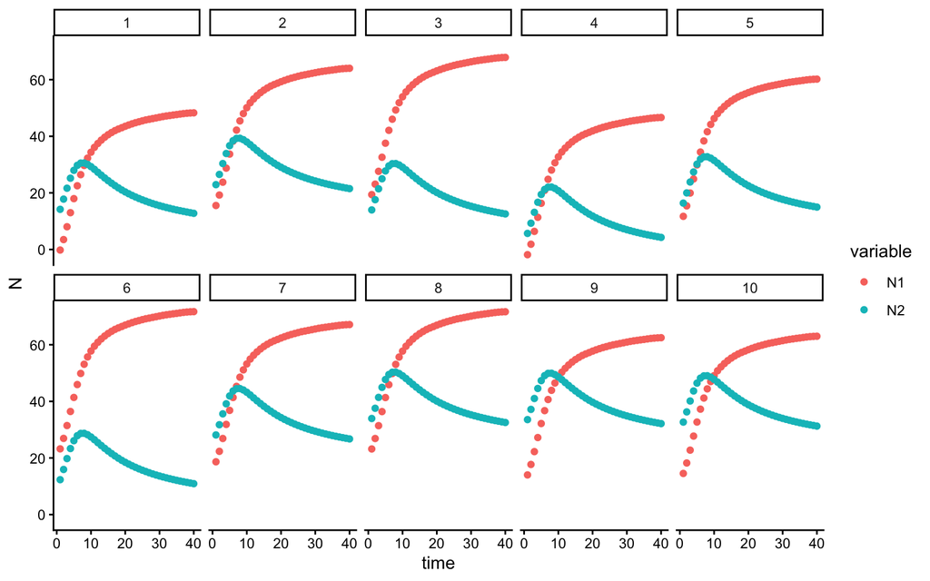

Population size over time for a discrete-time logistic growth model with competition, a changing environment, and trait evolution. Values are shown at 10 sites, with an increased site covariance in species abundances, depending on spatial distance.

```r
# Simulation of model for t time steps, i sites
N0 <- c(10, 10)
E.0 <- 0.8
x.0 <- c(0.1, 0.8)
alpha.11 <- 0.01
alpha.22 <- 0.01
alpha.12 <- 0.005
alpha.21 <- 0.01
alpha <- matrix(c(alpha.11, alpha.21, alpha.12, alpha.22), nrow = 2, byrow = FALSE)  # careful to make sure you have correct interaction matrix
P <- 1
w <- 2
Wmax <- 2
h2 <- 1
k <- (w + (1 - h2) * P)/(P + w)
j <- 10
# random site locations
xycoords = matrix(runif(2 * j), ncol = 2)
rownames(xycoords) <- 1:j
t <- 40
N <- array(NA, dim = c(j * t, length(N0)))
N <- as.data.frame(N)
colnames(N) <- paste0("N", 1:length(N0))
x <- array(NA, dim = c(j * t, length(N0)))
x <- as.data.frame(x)
colnames(x) <- paste0("x", 1:length(N0))
r <- array(NA, dim = c(j * t, length(N0)))
r <- as.data.frame(r)
colnames(r) <- paste0("r", 1:length(N0))
N[1:j, ] <- rep(N0, each = j)
E <- rep(NA, t)
E[1] <- E.0
x[1:j, ] <- rep(x.0, each = j)
What <- Wmax * sqrt(w/(P + w))
r0 <- as.numeric(What * exp((-(((w + (1 - h2) * P)/(P + w)) * (E[1] - x[1, ]))^2)/(2 *
    (P + w))))
r[1:j, ] <- rep(r0, each = j)
# Keep track of site and time
study <- array(NA, dim = c(j * t, 3))
study <- as.data.frame(study)
colnames(study) <- c("obs", "site", "time")
study$obs <- 1:dim(study)[1]
study$site <- rep(1:j, times = t)
study$time <- rep(1:t, each = j)

for (i in 2:t) {
    for (z in 1:j) {
        res <- disc_LV_evol(N0 = N[study$site == z & study$time == i - 1, ], alpha = alpha,
            E = E[i - 1], x = x[study$site == z & study$time == i - 1, ], P = P,
            w = w, Wmax = Wmax, h2 = h2)
        N[study$site == z & study$time == i, ] <- res$Nt1
        r[study$site == z & study$time == i, ] <- res$r
        # trait change
        d <- E[i - 1] - x[study$site == z & study$time == i - 1, ]
        d1 <- k * d
        x[study$site == z & study$time == i, ] <- E[i - 1] - d1
    }
    # environmental change
    E[i] <- E[i - 1] + abs(rnorm(1, 0, 0.05))
}
# site-level random effect
sigma <- 0
sigma.spatial <- 10
alpha.spatial <- 0.5
Sigma = sigma.spatial^2 * exp(-as.matrix(dist(xycoords))/alpha.spatial)
# draw from covariance matrix
a = mvrnorm(mu = rep(0, j), Sigma = Sigma)
for (i in 1:t) {
    N$N1[study$time == i] <- N$N1[study$time == i] + a
}
a = mvrnorm(mu = rep(0, j), Sigma = Sigma)
for (i in 1:t) {
    N$N2[study$time == i] <- N$N2[study$time == i] + a
}
```

```r
# prepare data in HMSC format
dat <- as.data.frame(cbind(log(N), x))
dat$time <- study$time
df <- data.frame(cbind(dat$N1[dat$time != 1], dat$N2[dat$time != 1], dat$x1[dat$time !=
    1], dat$x2[dat$time != 1]))
colnames(df) <- c("Nt1", "Nt2", "xt1", "xt2")
Y <- as.matrix(cbind(df$Nt1, df$Nt2))
XData <- data.frame(E = rep(E[1:(t - 1)], each = j))
XData$Esq <- XData$E^2
XData$dx1 <- abs(dat$x1[dat$time != 1] - dat$x1[dat$time != t])
XData$dx2 <- abs(dat$x2[dat$time != 1] - dat$x2[dat$time != t])
# Update study design to include spatial random effects
samp1 <- 1:(j * t)
samp1 <- as.data.frame(samp1)
samp1 <- subset(samp1, samp1 > 10)
rownames(XData) <- row.names(samp1)
studyDesign = data.frame(sample = 1:(j * (t - 1)), site = study$site[study$time >
    1])
studyDesign$sample <- as.factor(studyDesign$sample)
studyDesign$site <- as.factor(studyDesign$site)
rL.spatial = HmscRandomLevel(sData = xycoords)
rL.sample = HmscRandomLevel(units = studyDesign$sample)
# Fit HMSC model
m.10.hmsc = Hmsc(Y = Y, XData = XData, XFormula = ~E + Esq + dx1 + dx2, studyDesign = studyDesign,
    ranLevels = list(sample = rL.sample, site = rL.spatial))
# Bayesian model parameters
nChains <- 2
thin <- 5
samples <- 2000
transient <- 1000 * thin
verbose <- 500 * thin
# sample MCMC
m.10.sample <- sampleMcmc(m.10.hmsc, thin = thin, sample = samples, transient = transient,
    nChains = nChains, verbose = verbose)
```

```
#> Computing chain 1
#> Chain 1, iteration 2500 of 15000 (transient)
#> Chain 1, iteration 5000 of 15000 (transient)
#> Chain 1, iteration 7500 of 15000 (sampling)
#> Chain 1, iteration 10000 of 15000 (sampling)
#> Chain 1, iteration 12500 of 15000 (sampling)
#> Chain 1, iteration 15000 of 15000 (sampling)
#> Computing chain 2
#> Chain 2, iteration 2500 of 15000 (transient)
#> Chain 2, iteration 5000 of 15000 (transient)
#> Chain 2, iteration 7500 of 15000 (sampling)
#> Chain 2, iteration 10000 of 15000 (sampling)
#> Chain 2, iteration 12500 of 15000 (sampling)
#> Chain 2, iteration 15000 of 15000 (sampling)
```

```r
m10.post.hmsc <- convertToCodaObject(m.10.sample)
summary(m10.post.hmsc$Beta)
```

```
#>
#> Iterations = 5005:15000
#> Thinning interval = 5
#> Number of chains = 2
#> Sample size per chain = 2000
#>
#> 1. Empirical mean and standard deviation for each variable,
#>    plus standard error of the mean:
#>
#>                                  Mean      SD Naive SE Time-series SE
#> B[(Intercept) (C1), sp1 (S1)]  2.9037 0.23864 0.003773       0.006036
#> B[E (C2), sp1 (S1)]            1.1932 0.23928 0.003783       0.003783
#> B[Esq (C3), sp1 (S1)]         -0.3124 0.07922 0.001253       0.001253
#> B[dx1 (C4), sp1 (S1)]         -5.0230 0.28296 0.004474       0.004334
#> B[dx2 (C5), sp1 (S1)]          4.3581 0.70268 0.011110       0.011281
#> B[(Intercept) (C1), sp2 (S2)]  4.7748 0.37237 0.005888       0.015780
#> B[E (C2), sp2 (S2)]           -1.7581 0.20412 0.003227       0.003228
#> B[Esq (C3), sp2 (S2)]          0.3201 0.06714 0.001062       0.001062
#> B[dx1 (C4), sp2 (S2)]         -3.0965 0.23938 0.003785       0.003785
#> B[dx2 (C5), sp2 (S2)]          5.0031 0.58610 0.009267       0.008964
#>
#> 2. Quantiles for each variable:
#>
#>                                  2.5%     25%     50%     75%   97.5%
#> B[(Intercept) (C1), sp1 (S1)]  2.4081  2.7568  2.9161  3.0620  3.3443
#> B[E (C2), sp1 (S1)]            0.7209  1.0305  1.1919  1.3508  1.6691
#> B[Esq (C3), sp1 (S1)]         -0.4695 -0.3647 -0.3122 -0.2588 -0.1571
#> B[dx1 (C4), sp1 (S1)]         -5.5829 -5.2148 -5.0246 -4.8356 -4.4614
#> B[dx2 (C5), sp1 (S1)]          2.9563  3.8990  4.3583  4.8515  5.7198
#> B[(Intercept) (C1), sp2 (S2)]  3.9151  4.5601  4.8213  5.0247  5.3900
#> B[E (C2), sp2 (S2)]           -2.1606 -1.8942 -1.7550 -1.6276 -1.3590
#> B[Esq (C3), sp2 (S2)]          0.1871  0.2771  0.3189  0.3654  0.4529
#> B[dx1 (C4), sp2 (S2)]         -3.5585 -3.2540 -3.0975 -2.9362 -2.6164
#> B[dx2 (C5), sp2 (S2)]          3.8458  4.6049  5.0035  5.3946  6.1319
```

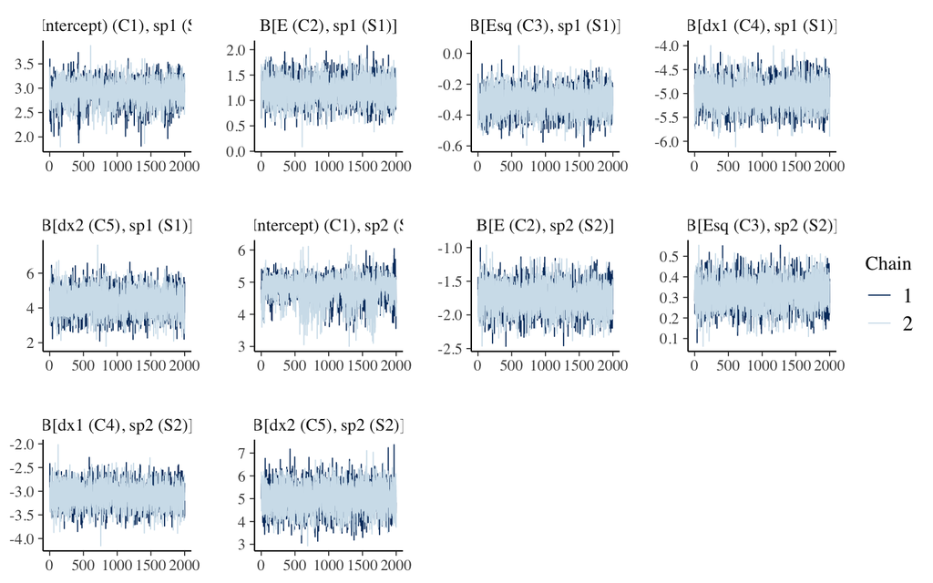

```r
bayesplot::mcmc_trace(m10.post.hmsc$Beta)
```

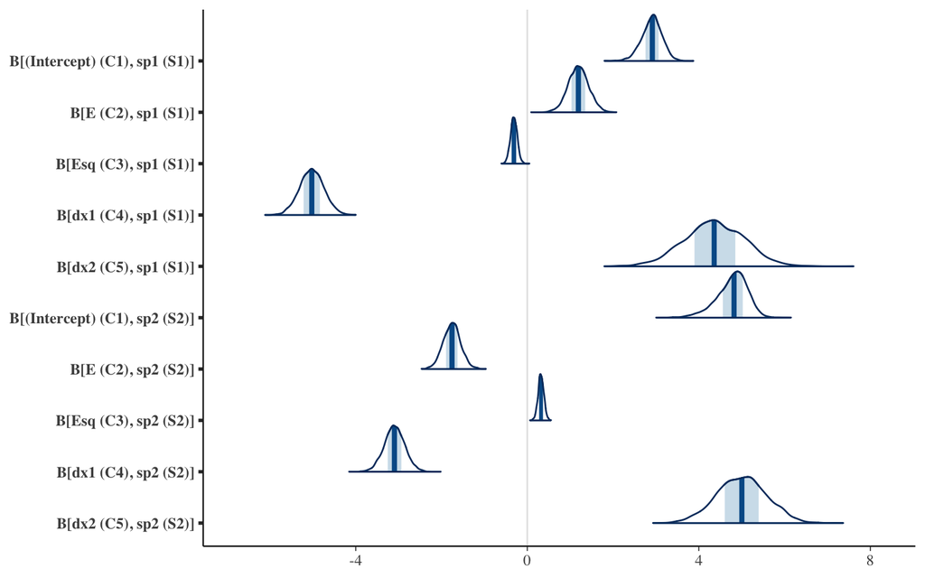

```r
bayesplot::mcmc_areas(m10.post.hmsc$Beta, area_method = c("equal height"))
```

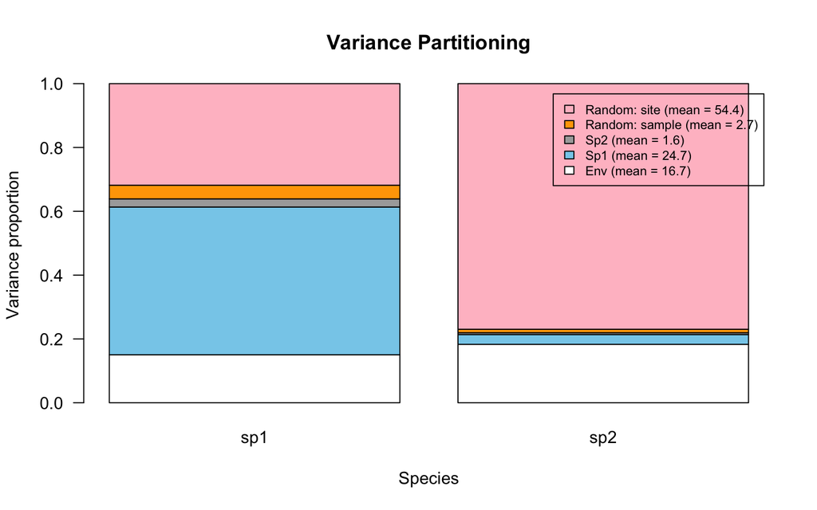

```r
VP <- computeVariancePartitioning(m.10.sample, group = c(1, 1, 1, 2, 3), groupnames = c("Env",
    "Sp1", "Sp2"))
plotVariancePartitioning(m.10.sample, VP, cols = c("white", "skyblue", "darkgrey",
    "orange", "pink"), args.legend = list(cex = 0.75, bg = "transparent"))
```

```r
OmegaCor = computeAssociations(m.9.sample)
supportLevel = 0.95
toPlot = ((OmegaCor[[1]]$support > supportLevel) + (OmegaCor[[1]]$support < (1 -
    supportLevel)) > 0) * OmegaCor[[1]]$mean
corrplot::corrplot(toPlot, method = "color", col = colorRampPalette(c("blue", "white",
    "red"))(200), title = paste("random effect level:", m.9.sample$rLNames[1]), mar = c(0,
    0, 1, 0))
```

```r
OmegaCor
```

```
#> [[1]]
#> [[1]]$mean
#>            sp1        sp2
#> sp1 1.00000000 0.05781371
#> sp2 0.05781371 1.00000000
#>
#> [[1]]$support
#>         sp1     sp2
#> sp1 1.00000 0.54275
#> sp2 0.54275 1.00000
#>
#>
#> [[2]]
#> [[2]]$mean
#>           sp1       sp2
#> sp1 1.0000000 0.1083981
#> sp2 0.1083981 1.0000000
#>
#> [[2]]$support
#>         sp1     sp2
#> sp1 1.00000 0.60525
#> sp2 0.60525 1.00000
```

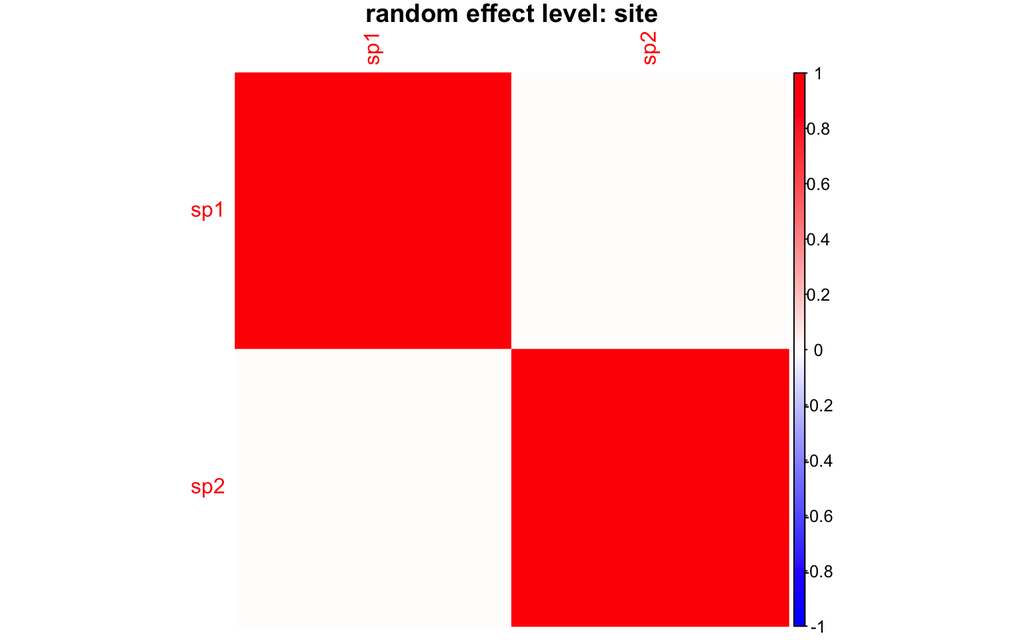

```r
toPlot = ((OmegaCor[[2]]$support > supportLevel) + (OmegaCor[[2]]$support < (1 -
    supportLevel)) > 0) * OmegaCor[[2]]$mean
corrplot::corrplot(toPlot, method = "color", col = colorRampPalette(c("blue", "white",
    "red"))(200), title = paste("random effect level:", m.9.sample$rLNames[2]), mar = c(0,
    0, 1, 0))
```

## Conclusions

We observe a much greater fraction of variation explained by the spatial random effects when the degree of spatial autocorrelation is higher, as expected.

# Summaries across all models

```r
### Model A, coefficient posteriors and R2
summar <- rbind(m.post.hmsc$Beta[[1]], m.post.hmsc$Beta[[2]])
mean(summar[, 2])
```

```
#> [1] 0.8472922
```

```r
quantile(summar[, 2], probs = c(0.05, 0.95))
```

```
#>        5%       95%
#> 0.8303614 0.8653093
```

```r
# Evaluate model fit
preds = computePredictedValues(m.1.sample)
MF = evaluateModelFit(hM = m.1.sample, predY = preds)
MF
```

```
#> $RMSE
#> [1] 0.05662102
#>
#> $R2
#> [1] 0.9966499
```

```r
### Model B, coefficient posteriors and R2
summar <- rbind(m2.post.hmsc$Beta[[1]], m2.post.hmsc$Beta[[2]])
# N
mean(summar[, 2])
```

```
#> [1] 0.8521043
```

```r
quantile(summar[, 2], probs = c(0.05, 0.95))
```

```
#>        5%       95%
#> 0.8335120 0.8706103
```

```r
# E
mean(summar[, 3])
```

```
#> [1] 2.549645
```

```r
quantile(summar[, 3], probs = c(0.05, 0.95))
```

```
#>          5%         95%
#> -0.03617611  5.10826429
```

```r
# E^2
mean(summar[, 4])
```

```
#> [1] -1.492359
```

```r
quantile(summar[, 4], probs = c(0.05, 0.95))
```

```
#>         5%        95%
#> -2.7840058 -0.2200474
```

```r
# Evaluate model fit
preds = computePredictedValues(m.2.sample)
MF = evaluateModelFit(hM = m.2.sample, predY = preds)
MF
```

```
#> $RMSE
#> [1] 0.04510726
#>
#> $R2
#> [1] 0.9971375
```

```r
### Model C, Scenario 1, coefficient posteriors and R2 Bayesian model
### parameters
nChains <- 2
thin <- 5
samples <- 1000
transient <- 500 * thin
verbose <- 500 * thin
# sample MCMC
m.3a1.sample <- sampleMcmc(m.3a1.hmsc, thin = thin, sample = samples, transient = transient,
    nChains = nChains, verbose = verbose)
```

```
#> setting updater$GammaEta=FALSE due to absence of random effects included to the model
#> Computing chain 1
#> Chain 1, iteration 2500 of 7500 (transient)
#> Chain 1, iteration 5000 of 7500 (sampling)
#> Chain 1, iteration 7500 of 7500 (sampling)
#> Computing chain 2
#> Chain 2, iteration 2500 of 7500 (transient)
#> Chain 2, iteration 5000 of 7500 (sampling)
#> Chain 2, iteration 7500 of 7500 (sampling)
```

```r
m.3a2.sample <- sampleMcmc(m.3a2.hmsc, thin = thin, sample = samples, transient = transient,
    nChains = nChains, verbose = verbose)
```

```
#> setting updater$GammaEta=FALSE due to absence of random effects included to the model
#> Computing chain 1
#> Chain 1, iteration 2500 of 7500 (transient)
#> Chain 1, iteration 5000 of 7500 (sampling)
#> Chain 1, iteration 7500 of 7500 (sampling)
#> Computing chain 2
#> Chain 2, iteration 2500 of 7500 (transient)
#> Chain 2, iteration 5000 of 7500 (sampling)
#> Chain 2, iteration 7500 of 7500 (sampling)
## N1 model
```

```r
m3a1.post.hmsc <- convertToCodaObject(m.3a1.sample)
# Summary statistics for main manuscript text
summar <- rbind(m3a1.post.hmsc$Beta[[1]], m3a1.post.hmsc$Beta[[2]])
# N1
mean(summar[, 2])
```

```
#> [1] 0.9201089
```

```r
quantile(summar[, 2], probs = c(0.05, 0.95))
```

```
#>        5%       95%
#> 0.9029134 0.9378984
```

```r
# N2
mean(summar[, 3])
```

```
#> [1] -0.144497
```

```r
quantile(summar[, 3], probs = c(0.05, 0.95))
```

```
#>         5%        95%
#> -0.1619870 -0.1269069
```

```r
# Evaluate model fit
preds = computePredictedValues(m.3a1.sample)
MF = evaluateModelFit(hM = m.3a1.sample, predY = preds)
MF
```

```
#> $RMSE
#> [1] 0.03400821
#>
#> $R2
#> [1] 0.9966022
```

```r
## N2 model
m3a2.post.hmsc <- convertToCodaObject(m.3a2.sample)
# Summary statistics for main manuscript text
summar <- rbind(m3a2.post.hmsc$Beta[[1]], m3a2.post.hmsc$Beta[[2]])
# N1
mean(summar[, 2])
```

```
#> [1] -0.3397628
```

```r
quantile(summar[, 2], probs = c(0.05, 0.95))
```

```
#>         5%        95%
#> -0.3527640 -0.3266132
```

```r
# N2
mean(summar[, 3])
```

```
#> [1] 1.092959
```

```r
quantile(summar[, 3], probs = c(0.05, 0.95))
```

```
#>       5%      95%
#> 1.080589 1.105286
```

```r
# Evaluate model fit
preds = computePredictedValues(m.3a2.sample)
MF = evaluateModelFit(hM = m.3a2.sample, predY = preds)
MF
```

```
#> $RMSE
#> [1] 0.0191066
#>
#> $R2
#> [1] 0.9993467
```

```r
### Model C, Scenario 2, coefficient posteriors and R2 sample MCMC
m.4a1.sample <- sampleMcmc(m.4a1.hmsc, thin = thin, sample = samples, transient = transient,
    nChains = nChains, verbose = verbose)
```

```
#> setting updater$GammaEta=FALSE due to absence of random effects included to the model
#> Computing chain 1
#> Chain 1, iteration 2500 of 7500 (transient)
#> Chain 1, iteration 5000 of 7500 (sampling)
#> Chain 1, iteration 7500 of 7500 (sampling)
#> Computing chain 2
#> Chain 2, iteration 2500 of 7500 (transient)
#> Chain 2, iteration 5000 of 7500 (sampling)
#> Chain 2, iteration 7500 of 7500 (sampling)
```

```r
m.4a2.sample <- sampleMcmc(m.4a2.hmsc, thin = thin, sample = samples, transient = transient,
    nChains = nChains, verbose = verbose)
```

```
#> setting updater$GammaEta=FALSE due to absence of random effects included to the model
#> Computing chain 1
#> Chain 1, iteration 2500 of 7500 (transient)
#> Chain 1, iteration 5000 of 7500 (sampling)
#> Chain 1, iteration 7500 of 7500 (sampling)
#> Computing chain 2
#> Chain 2, iteration 2500 of 7500 (transient)
#> Chain 2, iteration 5000 of 7500 (sampling)
#> Chain 2, iteration 7500 of 7500 (sampling)
```

```r
# Summary properties for main manuscript text
preds = computePredictedValues(m.4a1.sample)
MF = evaluateModelFit(hM = m.4a1.sample, predY = preds)
MF
```

```
#> $RMSE
#> [1] 0.007505173
#>
#> $R2
#> [1] 0.9994649
```

```r
# Summary properties for main manuscript text
preds = computePredictedValues(m.4a2.sample)
MF = evaluateModelFit(hM = m.4a2.sample, predY = preds)
MF
```

```
#> $RMSE
#> [1] 0.006784049
#>
#> $R2
#> [1] 0.9996631
```

```r
### Model D, Scenario 1, coefficient posteriors and R2 sample MCMC
m.5a1.sample <- sampleMcmc(m.5a1.hmsc, thin = thin, sample = samples, transient = transient,
    nChains = nChains, verbose = verbose)
```

```
#> setting updater$GammaEta=FALSE due to absence of random effects included to the model
#> Computing chain 1
#> Chain 1, iteration 2500 of 7500 (transient)
#> Chain 1, iteration 5000 of 7500 (sampling)
#> Chain 1, iteration 7500 of 7500 (sampling)
#> Computing chain 2
#> Chain 2, iteration 2500 of 7500 (transient)
#> Chain 2, iteration 5000 of 7500 (sampling)
#> Chain 2, iteration 7500 of 7500 (sampling)
```

```r
m.5a2.sample <- sampleMcmc(m.5a2.hmsc, thin = thin, sample = samples, transient = transient,
    nChains = nChains, verbose = verbose)
```

```
#> setting updater$GammaEta=FALSE due to absence of random effects included to the model
#> Computing chain 1
#> Chain 1, iteration 2500 of 7500 (transient)
#> Chain 1, iteration 5000 of 7500 (sampling)
#> Chain 1, iteration 7500 of 7500 (sampling)
#> Computing chain 2
#> Chain 2, iteration 2500 of 7500 (transient)
#> Chain 2, iteration 5000 of 7500 (sampling)
#> Chain 2, iteration 7500 of 7500 (sampling)
```

```r
# Summary properties for main manuscript text
preds = computePredictedValues(m.5a1.sample)
MF = evaluateModelFit(hM = m.5a1.sample, predY = preds)
MF
```

```
#> $RMSE
#> [1] 0.01308271
#>
#> $R2
#> [1] 0.9997964
```

```r
# Summary properties for main manuscript text
preds = computePredictedValues(m.5a2.sample)
MF = evaluateModelFit(hM = m.5a2.sample, predY = preds)
MF
```

```
#> $RMSE
#> [1] 0.01275543
#>
#> $R2
#> [1] 0.9976463
```

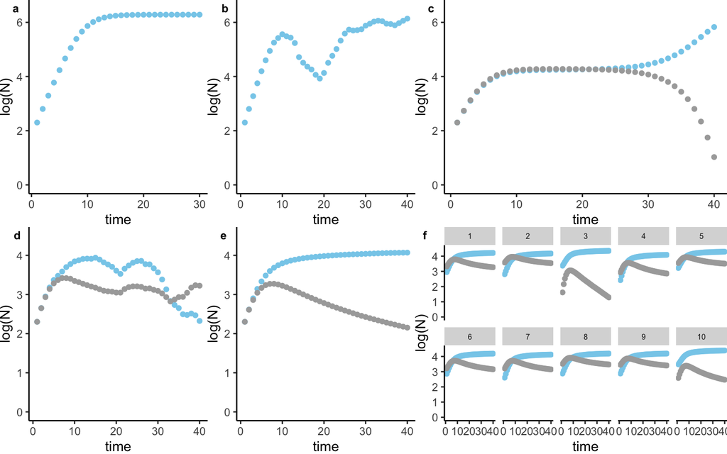

# References

Beverton, R. J., and S. J. Holt. 1957. On the dynamics of exploited fish populations (Vol. 11). Springer Science & Business Media.

Certain, G., F. Barraquand, and A. Gårdmark. 2018. [How do MAR(1) models cope with hidden nonlinearities in ecological dynamics?](https://doi.org/10.1111/2041-210X.13021) Methods in Ecology and Evolution 9:1975–1995.

Erickson, K. D., and A. B. Smith. 2023. [Modeling the rarest of the rare: A comparison between multi-species distribution models, ensembles of small models, and single-species models at extremely low sample sizes](https://doi.org/10.1111/ecog.06500). Ecography 2023:e06500.

Gomulkiewicz, R., and R. D. Holt. 1995. [When does evolution by natural selection prevent extinction?](http://www.jstor.org/stable/2410305) Evolution 49:201–207.

Hart, S. P., and D. J. Marshall. 2013. [Environmental stress, facilitation, competition, and coexistence](https://doi.org/10.1890/12-0804.1). Ecology 94:2719–2731.

Ingram, M., D. Vukcevic, and N. Golding. 2020. [Multi-output gaussian processes for species distribution modelling](https://doi.org/10.1111/2041-210X.13496). Methods in Ecology and Evolution 11:1587–1598.

Ives, A. R. 1995. [Predicting the response of populations to environmental change](https://doi.org/10.2307/1939357). Ecology 76:926–941.

Kloppers, P. H., and J. C. Greeff. 2013. [Lotka–volterra model parameter estimation using experiential data](https://doi.org/10.1016/j.amc.2013.08.093). Applied Mathematics and Computation 224:817–825.

Mühlbauer, L. K., M. Schulze, W. S. Harpole, and A. T. Clark. 2020. [gauseR: Simple methods for fitting lotka-volterra models describing gause’s “struggle for existence”](https://doi.org/10.1002/ece3.6926). Ecology and Evolution 10:13275–13283.

Olivença, D. V., J. D. Davis, and E. O. Voit. 2021. [Comparison between lotka-volterra and multivariate autoregressive models of ecological interaction systems](https://doi.org/10.1101/2021.10.07.463461). bioRxiv.

Ovaskainen, O., and N. Abrego. 2020. [Joint species distribution modelling: With applications in r](https://doi.org/10.1017/9781108591720). Ecology biodiversity and conservation. Cambridge University Press, United Kingdom.

Ovaskainen, O., G. Tikhonov, D. Dunson, V. Grøtan, S. Engen, B.-E. Sæther, and N. Abrego. 2017. [How are species interactions structured in species-rich communities? A new method for analysing time-series data](https://doi.org/10.1098/rspb.2017.0768). Proceedings of the Royal Society B: Biological Sciences 284:20170768.

[^1]: Université Marie et Louis Pasteur, CNRS, Chrono-environnement (UMR 6249), F-25000 Besançon, France, jelena.pantel@umlp.fr
[^2]: Aquatic Ecology and Evolution Group, Limnological Institute, Department of Biology, University of Konstanz, Universitaetsstrasse 10, 78464 Konstanz, Germany, ruben.hermann@posteo.de